# SCFA_boxplots: Kruskal Wallis test with Dunn´s post-hoc test

Anna Michl

30 3 2026

Load all packages needed

```r
library(dplyr)
```

```r
library(readxl)
library(ggplot2)
library(ggpubr)  # for stats annotations
library(RColorBrewer)
library(viridis)
library(patchwork)
library(rstatix)
```

Set working directory (ADJUST TO YOUR PATH TO THE .XLSX FILE)

```r
setwd("Y:/1537-Schwarzer/Anna/SCFAs_interlab_validation/")
path <- "Y:/1537-Schwarzer/Anna/SCFAs_interlab_validation/NORWAY_QUANTIFICATION.xlsx"
R.version
```

```
##                _
## platform       x86_64-w64-mingw32
## arch           x86_64
## os             mingw32
## crt            ucrt
## system         x86_64, mingw32
## status
## major          4
## minor          4.1
## year           2024
## month          06
## day            14
## svn rev        86737
## language       R
## version.string R version 4.4.1 (2024-06-14 ucrt)
## nickname       Race for Your Life
```

# L A C T A T E

Import the dataset and exclude blanks

```r
lactate <- read_excel("NORWAY_QUANTIFICATION.xlsx", sheet = "NEW_LACTATE") %>%
  as.data.frame() %>%
  mutate(`MEDIAN_REL_AREA_NORMALIZED` = as.numeric(`MEDIAN_REL_AREA_NORMALIZED`)) %>%
  filter(COHORT != "Blank")  # Remove rows where COHORT is "Blank"
```

Filter only values Rep1 in the column replicate and exclude samples CV5 and CV6

```r
lactate <- lactate %>%
  filter(REPLICATE == "Rep1", !TYPE %in% c("CV5", "CV6"))
```

Define color palette

```r
N <- length(unique(lactate$TYPE))
my_palette <- viridis(N, option = "A")
desired_order <- c("GF_CZ", "Ba_CZ", "OMM12_CZ", "SPF_CZ", "GF_NO", "Ba_NO" , "OMM12_NO", "SPF_NO")
lactate$COHORT <- factor(lactate$COHORT, levels = desired_order)
```

Select color palette for all the graphs

```r
my_palette_fill <- c("cornflowerblue", "orchid3", "maroon", "lightblue1" ,"cornflowerblue", "orchid3",  "maroon", "lightblue1")
my_palette_color <- c(
  "red4", "skyblue4", "navy", "goldenrod2", "darkolivegreen", "darkorange", "salmon", "violet", "lightsalmon3",
  "red4", "skyblue4", "goldenrod2", "darkolivegreen", "darkorange", "purple4", "lightyellow", "seagreen3", "indianred",
  "red4", "skyblue4", "navy", "goldenrod2",
  "red4" , "skyblue4",  "navy", "goldenrod2")
```

Remove zero or negative values

```r
lactate <- lactate %>% filter(`MEDIAN_REL_AREA_NORMALIZED` > 0)
lactate$COHORT <- factor(lactate$COHORT, levels = desired_order)
lactate$TYPE   <- factor(lactate$TYPE)
levels(lactate$COHORT)
```

```
## [1] "GF_CZ"    "Ba_CZ"    "OMM12_CZ" "SPF_CZ"   "GF_NO"    "Ba_NO"    "OMM12_NO"
## [8] "SPF_NO"
```

```r
levels(lactate$TYPE)
```

```
##  [1] "368-1" "368-2" "368-3" "368-4" "373-1" "373-2" "373-3" "373-4" "CV1"
## [10] "CV10"  "CV2"   "CV3"   "CV4"   "CV7"   "CV8"   "CV9"   "GF1"   "GF2"
## [19] "GF3"   "GF4"   "OMM1"  "OMM2"  "OMM3"  "OMM4"
```

Are there overall difference among cohorts from CZ dataset?

```r
kruskal.test(MEDIAN_REL_AREA_NORMALIZED ~ COHORT,
             data = subset(lactate, COUNTRY == "CZ"))
```

```
##
##  Kruskal-Wallis rank sum test
##
## data:  MEDIAN_REL_AREA_NORMALIZED by COHORT
## Kruskal-Wallis chi-squared = 18.368, df = 3, p-value = 0.0003694
```

Are there overall difference among cohorts from NO dataset?

```r
kruskal.test(MEDIAN_REL_AREA_NORMALIZED ~ COHORT,
             data = subset(lactate, COUNTRY == "NO"))
```

```
##
##  Kruskal-Wallis rank sum test
##
## data:  MEDIAN_REL_AREA_NORMALIZED by COHORT
## Kruskal-Wallis chi-squared = 19.267, df = 3, p-value = 0.0002407
```

Run Dunn test, and only consider differences within CZ or NO data, not mixing them together

```r
dunn_results <- lactate %>%
 group_by(COUNTRY) %>%
 dunn_test(MEDIAN_REL_AREA_NORMALIZED ~ COHORT,
 p.adjust.method = "BH")
dunn_results
```

```
## # A tibble: 12 × 10
##    COUNTRY .y.               group1 group2    n1    n2 statistic       p   p.adj
##  * <chr>   <chr>             <chr>  <chr>  <int> <int>     <dbl>   <dbl>   <dbl>
##  1 CZ      MEDIAN_REL_AREA_… GF_CZ  Ba_CZ      4     8     3.98  6.78e-5 4.07e-4
##  2 CZ      MEDIAN_REL_AREA_… GF_CZ  OMM12…     4     4     1.55  1.21e-1 1.51e-1
##  3 CZ      MEDIAN_REL_AREA_… GF_CZ  SPF_CZ     4     8     1.53  1.26e-1 1.51e-1
##  4 CZ      MEDIAN_REL_AREA_… Ba_CZ  OMM12…     8     4    -2.19  2.82e-2 5.65e-2
##  5 CZ      MEDIAN_REL_AREA_… Ba_CZ  SPF_CZ     8     8    -3.01  2.65e-3 7.96e-3
##  6 CZ      MEDIAN_REL_AREA_… OMM12… SPF_CZ     4     8    -0.260 7.95e-1 7.95e-1
##  7 NO      MEDIAN_REL_AREA_… GF_NO  Ba_NO      4     8     3.06  2.21e-3 6.64e-3
##  8 NO      MEDIAN_REL_AREA_… GF_NO  OMM12…     4     4     1.45  1.47e-1 1.99e-1
##  9 NO      MEDIAN_REL_AREA_… GF_NO  SPF_NO     4     8    -0.260 7.95e-1 7.95e-1
## 10 NO      MEDIAN_REL_AREA_… Ba_NO  OMM12…     8     4    -1.39  1.66e-1 1.99e-1
## 11 NO      MEDIAN_REL_AREA_… Ba_NO  SPF_NO     8     8    -4.07  4.79e-5 2.87e-4
## 12 NO      MEDIAN_REL_AREA_… OMM12… SPF_NO     4     8    -1.93  5.31e-2 1.06e-1
## # ℹ 1 more variable: p.adj.signif <chr>
```

Now only select the comparisons where some significance occured

```r
dunn_results_sig <- dunn_results %>%
dplyr::filter(p.adj.signif != "ns")
dunn_results_sig <- dunn_results_sig %>%
mutate(y.position = c(300, 1000,  300, 1000))
dunn_results_sig
```

```
## # A tibble: 4 × 11
##   COUNTRY .y.   group1 group2    n1    n2 statistic       p   p.adj p.adj.signif
##   <chr>   <chr> <chr>  <chr>  <int> <int>     <dbl>   <dbl>   <dbl> <chr>
## 1 CZ      MEDI… GF_CZ  Ba_CZ      4     8      3.98 6.78e-5 4.07e-4 ***
## 2 CZ      MEDI… Ba_CZ  SPF_CZ     8     8     -3.01 2.65e-3 7.96e-3 **
## 3 NO      MEDI… GF_NO  Ba_NO      4     8      3.06 2.21e-3 6.64e-3 **
## 4 NO      MEDI… Ba_NO  SPF_NO     8     8     -4.07 4.79e-5 2.87e-4 ***
## # ℹ 1 more variable: y.position <dbl>
```

```r
dunn_results_sig$group1
```

```
## [1] "GF_CZ" "Ba_CZ" "GF_NO" "Ba_NO"
```

Create a lookup for x positions

```r
cohort_positions <- data.frame(
  COHORT = levels(factor(lactate$COHORT,
                         levels = c("GF_CZ","Ba_CZ","OMM12_CZ","SPF_CZ",
                                    "GF_NO","Ba_NO","OMM12_NO","SPF_NO"))),
  x = 1:8)
```

Map x positions

```r
dunn_results_sig <- dunn_results_sig %>%
  left_join(cohort_positions, by = c("group1" = "COHORT")) %>%
  rename(xmin = x) %>%
  left_join(cohort_positions, by = c("group2" = "COHORT")) %>%
  rename(xmax = x) %>%
  mutate(y.position = c(300, 1000, 300, 1000))
dunn_results_sig <- dunn_results_sig %>%
  mutate(y.text = y.position * 1.2)
```

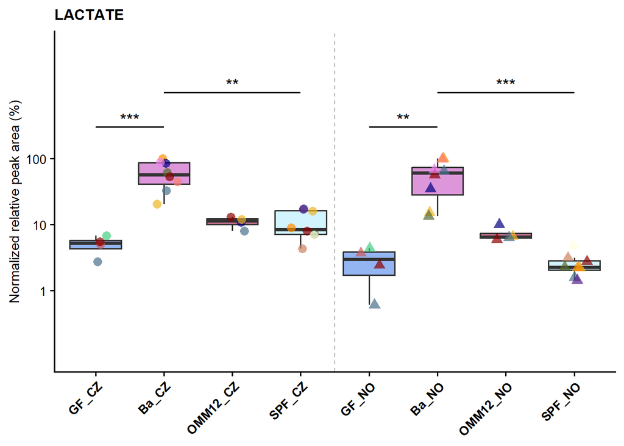

```r
ggplot(lactate, aes(x = COHORT, y = MEDIAN_REL_AREA_NORMALIZED, fill = COHORT)) +
  geom_boxplot(alpha = 0.7, outlier.shape = NA, show.legend = FALSE) +
  geom_vline(xintercept = 4.5, linetype = "dashed", linewidth = 0.5, color = "darkgrey") +
  geom_jitter(aes(color = TYPE, shape = COUNTRY),
              width = 0.2, size = 3, alpha = 0.7, show.legend = FALSE) +
  geom_segment(data = dunn_results_sig,
               aes(x = xmin, xend = xmax, y = y.position, yend = y.position),
               inherit.aes = FALSE) +
  geom_text(data = dunn_results_sig,
            aes(x = (xmin + xmax)/2, y = y.position, label = p.adj.signif),
            inherit.aes = FALSE, vjust = -0.1) +
  scale_color_manual(values = my_palette_color) +
  scale_shape_manual(values = c("CZ" = 16, "NO" = 17)) +
  scale_fill_manual(values = my_palette_fill) +
  scale_y_log10(breaks = c(1,10,100)) +
  coord_cartesian(ylim = c(0.1,5000)) +
  theme_classic(base_size = 14) +
   labs(title = "LACTATE", y = "Normalized relative peak area (%)")+
   theme(
    plot.title   = element_text(size = 12, face = "bold"),
    axis.title.x = element_blank(),
    axis.title.y = element_text(size = 11, colour = "black"),
    axis.text.x = element_text(size = 10, face = "bold", angle = 45, hjust = 1, colour = "black"),
    axis.text.y  = element_text(size = 10, colour = "black")
  )
```

Save as a variable

```r
Lactate_boxplots_KW <- ggplot(lactate, aes(x = COHORT, y = MEDIAN_REL_AREA_NORMALIZED, fill = COHORT)) +
  geom_boxplot(alpha = 0.7, outlier.shape = NA, show.legend = FALSE) +
  geom_vline(xintercept = 4.5, linetype = "dashed", linewidth = 0.5, color = "darkgrey") +
  geom_jitter(aes(color = TYPE, shape = COUNTRY),
              width = 0.2, size = 2, alpha = 0.7, show.legend = FALSE) +
  geom_segment(data = dunn_results_sig,
             aes(x = xmin, xend = xmax, y = y.position, yend = y.position),
             inherit.aes = FALSE) +
  geom_text(data = dunn_results_sig,
          aes(x = (xmin + xmax)/2, y = y.text, label = p.adj.signif),
          inherit.aes = FALSE) +
  scale_color_manual(values = my_palette_color) +
  scale_shape_manual(values = c("CZ" = 16, "NO" = 17)) +
  scale_fill_manual(values = my_palette_fill) +
  scale_y_log10(breaks = c(1,10,100)) +
  coord_cartesian(ylim = c(0.1,5000)) +
  theme_classic(base_size = 14) +
   labs(title = "LACTATE", y = "Normalized relative peak area (%)")+
   theme(
    plot.title   = element_text(size = 12, face = "bold"),
    axis.title.x = element_blank(),
    axis.title.y = element_text(size = 11, colour = "black"),
    axis.text.x = element_text(size = 10, face = "bold", angle = 45, hjust = 1, colour = "black"),
    axis.text.y  = element_text(size = 10, colour = "black"))

ggsave("Lactate_boxplots_KW.png",
       plot = Lactate_boxplots_KW,
       width = 10, height = 10, dpi = 300)
```

# A C E T A T E

Import the dataset and exclude blanks

```r
acetate <- read_excel("NORWAY_QUANTIFICATION.xlsx", sheet = "NEW_ACETATE") %>%
  as.data.frame() %>%
  mutate(`MEDIAN_REL_AREA_NORMALIZED` = as.numeric(`MEDIAN_REL_AREA_NORMALIZED`)) %>%
  filter(COHORT != "Blank")  # Remove rows where COHORT is "Blank"
```

Filter only values Rep1 in the column replicate and exclude samples CV5 and CV6

```r
acetate <- acetate %>%
  filter(REPLICATE == "Rep1", !TYPE %in% c("CV5", "CV6"))
```

Define color palette

```r
N <- length(unique(acetate$TYPE))
acetate$COHORT <- factor(acetate$COHORT, levels = desired_order)
```

Remove zero or negative values

```r
acetate <- acetate %>% filter(`MEDIAN_REL_AREA_NORMALIZED` > 0)
acetate$COHORT <- factor(acetate$COHORT, levels = desired_order)
acetate$TYPE   <- factor(acetate$TYPE)
levels(acetate$COHORT)
```

```
## [1] "GF_CZ"    "Ba_CZ"    "OMM12_CZ" "SPF_CZ"   "GF_NO"    "Ba_NO"    "OMM12_NO"
## [8] "SPF_NO"
```

```r
levels(acetate$TYPE)
```

```
##  [1] "368-1" "368-2" "368-3" "368-4" "373-1" "373-2" "373-3" "373-4" "CV1"
## [10] "CV10"  "CV2"   "CV3"   "CV4"   "CV7"   "CV8"   "CV9"   "GF1"   "GF2"
## [19] "GF3"   "GF4"   "OMM1"  "OMM2"  "OMM3"  "OMM4"
```

Are there overall difference among cohorts from CZ dataset?

```r
kruskal.test(MEDIAN_REL_AREA_NORMALIZED ~ COHORT,
             data = subset(acetate, COUNTRY == "CZ"))
```

```
##
##  Kruskal-Wallis rank sum test
##
## data:  MEDIAN_REL_AREA_NORMALIZED by COHORT
## Kruskal-Wallis chi-squared = 20.888, df = 3, p-value = 0.0001111
```

Are there overall difference among cohorts from NO dataset?

```r
kruskal.test(MEDIAN_REL_AREA_NORMALIZED ~ COHORT,
             data = subset(acetate, COUNTRY == "NO"))
```

```
##
##  Kruskal-Wallis rank sum test
##
## data:  MEDIAN_REL_AREA_NORMALIZED by COHORT
## Kruskal-Wallis chi-squared = 20.047, df = 3, p-value = 0.0001659
```

Run Dunn test, and only consider differences within CZ or NO data, not mixing them together

```r
dunn_results <- acetate %>%
 group_by(COUNTRY) %>%
 dunn_test(MEDIAN_REL_AREA_NORMALIZED ~ COHORT,
 p.adjust.method = "BH")
dunn_results
```

```
## # A tibble: 12 × 10
##    COUNTRY .y.               group1 group2    n1    n2 statistic       p   p.adj
##  * <chr>   <chr>             <chr>  <chr>  <int> <int>     <dbl>   <dbl>   <dbl>
##  1 CZ      MEDIAN_REL_AREA_… GF_CZ  Ba_CZ      4     8      1.39 1.66e-1 1.94e-1
##  2 CZ      MEDIAN_REL_AREA_… GF_CZ  OMM12…     4     4      3.95 7.82e-5 4.69e-4
##  3 CZ      MEDIAN_REL_AREA_… GF_CZ  SPF_CZ     4     8      3.26 1.11e-3 2.99e-3
##  4 CZ      MEDIAN_REL_AREA_… Ba_CZ  OMM12…     8     4      3.18 1.50e-3 2.99e-3
##  5 CZ      MEDIAN_REL_AREA_… Ba_CZ  SPF_CZ     8     8      2.30 2.16e-2 3.23e-2
##  6 CZ      MEDIAN_REL_AREA_… OMM12… SPF_CZ     4     8     -1.30 1.94e-1 1.94e-1
##  7 NO      MEDIAN_REL_AREA_… GF_NO  Ba_NO      4     8      1.30 1.94e-1 2.33e-1
##  8 NO      MEDIAN_REL_AREA_… GF_NO  OMM12…     4     4      3.75 1.77e-4 1.06e-3
##  9 NO      MEDIAN_REL_AREA_… GF_NO  SPF_NO     4     8      3.29 9.99e-4 3.00e-3
## 10 NO      MEDIAN_REL_AREA_… Ba_NO  OMM12…     8     4      3.03 2.44e-3 4.87e-3
## 11 NO      MEDIAN_REL_AREA_… Ba_NO  SPF_NO     8     8      2.44 1.47e-2 2.21e-2
## 12 NO      MEDIAN_REL_AREA_… OMM12… SPF_NO     4     8     -1.04 2.99e-1 2.99e-1
## # ℹ 1 more variable: p.adj.signif <chr>
```

Now only select the comparisons where some significance occured

```r
dunn_results_sig <- dunn_results %>%
dplyr::filter(p.adj.signif != "ns")
dunn_results_sig <- dunn_results_sig %>%
mutate(y.position = c(300, 800, 2000, 4800, 300, 800, 2000, 4800))
dunn_results_sig
```

```
## # A tibble: 8 × 11
##   COUNTRY .y.   group1 group2    n1    n2 statistic       p   p.adj p.adj.signif
##   <chr>   <chr> <chr>  <chr>  <int> <int>     <dbl>   <dbl>   <dbl> <chr>
## 1 CZ      MEDI… GF_CZ  OMM12…     4     4      3.95 7.82e-5 4.69e-4 ***
## 2 CZ      MEDI… GF_CZ  SPF_CZ     4     8      3.26 1.11e-3 2.99e-3 **
## 3 CZ      MEDI… Ba_CZ  OMM12…     8     4      3.18 1.50e-3 2.99e-3 **
## 4 CZ      MEDI… Ba_CZ  SPF_CZ     8     8      2.30 2.16e-2 3.23e-2 *
## 5 NO      MEDI… GF_NO  OMM12…     4     4      3.75 1.77e-4 1.06e-3 **
## 6 NO      MEDI… GF_NO  SPF_NO     4     8      3.29 9.99e-4 3.00e-3 **
## 7 NO      MEDI… Ba_NO  OMM12…     8     4      3.03 2.44e-3 4.87e-3 **
## 8 NO      MEDI… Ba_NO  SPF_NO     8     8      2.44 1.47e-2 2.21e-2 *
## # ℹ 1 more variable: y.position <dbl>
```

```r
dunn_results_sig$group1
```

```
## [1] "GF_CZ" "GF_CZ" "Ba_CZ" "Ba_CZ" "GF_NO" "GF_NO" "Ba_NO" "Ba_NO"
```

Create a lookup for x positions

```r
cohort_positions <- data.frame(
  COHORT = levels(factor(acetate$COHORT,
                         levels = c("GF_CZ","Ba_CZ","OMM12_CZ","SPF_CZ",
                                    "GF_NO","Ba_NO","OMM12_NO","SPF_NO"))),
  x = 1:8)
```

Map x positions

```r
dunn_results_sig <- dunn_results_sig %>%
  left_join(cohort_positions, by = c("group1" = "COHORT")) %>%
  rename(xmin = x) %>%
  left_join(cohort_positions, by = c("group2" = "COHORT")) %>%
  rename(xmax = x) %>%
  mutate(y.position =  c(300, 800, 2000, 4800, 300, 800, 2000, 4800))
dunn_results_sig <- dunn_results_sig %>%
  mutate(y.text = y.position * 1.2)
```

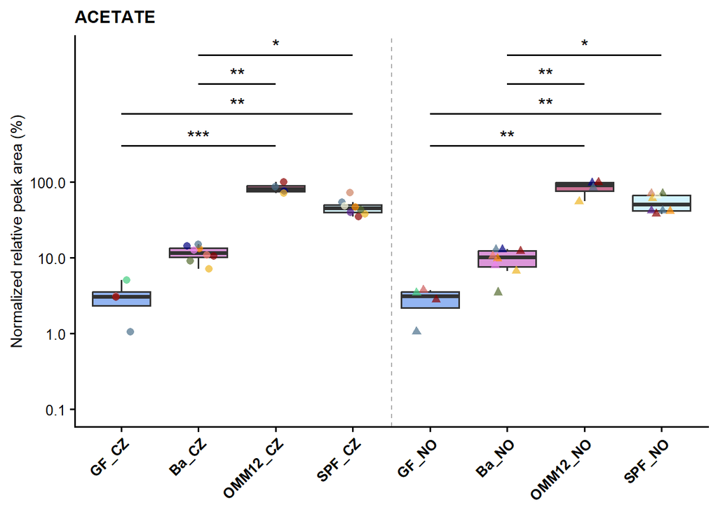

```r
ggplot(acetate, aes(x = COHORT, y = MEDIAN_REL_AREA_NORMALIZED, fill = COHORT)) +
  geom_boxplot(alpha = 0.7, outlier.shape = NA, show.legend = FALSE) +
  geom_vline(xintercept = 4.5, linetype = "dashed", linewidth = 0.5, color = "darkgrey") +
  geom_jitter(aes(color = TYPE, shape = COUNTRY),
              width = 0.2, size = 2, alpha = 0.7, show.legend = FALSE) +
  geom_segment(data = dunn_results_sig,
               aes(x = xmin, xend = xmax, y = y.position, yend = y.position),
               inherit.aes = FALSE) +
  geom_text(data = dunn_results_sig,
            aes(x = (xmin + xmax)/2, y = y.position, label = p.adj.signif),
            inherit.aes = FALSE, vjust = -0.1) +
  scale_color_manual(values = my_palette_color) +
  scale_shape_manual(values = c("CZ" = 16, "NO" = 17)) +
  scale_fill_manual(values = my_palette_fill) +
  scale_y_log10(breaks = c(0.1,1,10,100)) +
  coord_cartesian(ylim = c(0.1,5000)) +
  theme_classic(base_size = 14) +
   labs(title = "ACETATE", y = "Normalized relative peak area (%)")+
   theme(
    plot.title   = element_text(size = 12, face = "bold"),
    axis.title.x = element_blank(),
    axis.title.y = element_text(size = 11, colour = "black"),
    axis.text.x = element_text(size = 10, face = "bold", angle = 45, hjust = 1, colour = "black"),
    axis.text.y  = element_text(size = 10, colour = "black")
  )
```

Save as a variable

```r
Acetate_boxplots_KW <- ggplot(acetate, aes(x = COHORT, y = MEDIAN_REL_AREA_NORMALIZED, fill = COHORT)) +
  geom_boxplot(alpha = 0.7, outlier.shape = NA, show.legend = FALSE) +
  geom_vline(xintercept = 4.5, linetype = "dashed", linewidth = 0.5, color = "darkgrey") +
  geom_jitter(aes(color = TYPE, shape = COUNTRY),
              width = 0.2, size = 2, alpha = 0.7, show.legend = FALSE) +
  geom_segment(data = dunn_results_sig,
             aes(x = xmin, xend = xmax, y = y.position, yend = y.position),
             inherit.aes = FALSE) +
  geom_text(data = dunn_results_sig,
          aes(x = (xmin + xmax)/2, y = y.text, label = p.adj.signif),
          inherit.aes = FALSE) +
  scale_color_manual(values = my_palette_color) +
  scale_shape_manual(values = c("CZ" = 16, "NO" = 17)) +
  scale_fill_manual(values = my_palette_fill) +
  scale_y_log10(breaks = c(1,10,100)) +
  coord_cartesian(ylim = c(0.1,5000)) +
  theme_classic(base_size = 14) +
   labs(title = "ACETATE", y = "Normalized relative peak area (%)")+
   theme(
    plot.title   = element_text(size = 12, face = "bold"),
    axis.title.x = element_blank(),
    axis.title.y = element_text(size = 11, colour = "black"),
    axis.text.x = element_text(size = 10, face = "bold", angle = 45, hjust = 1, colour = "black"),
    axis.text.y  = element_text(size = 10, colour = "black"))

ggsave("Acetate_boxplots_KW.png",
       plot = Acetate_boxplots_KW,
       width = 10, height = 10, dpi = 300)
```

# P R O P I O N A T E

Import the dataset and exclude blanks

```r
propionate <- read_excel("NORWAY_QUANTIFICATION.xlsx", sheet = "NEW_PROPIONATE") %>%
  as.data.frame() %>%
  mutate(`MEDIAN_REL_AREA_NORMALIZED` = as.numeric(`MEDIAN_REL_AREA_NORMALIZED`)) %>%
  filter(COHORT != "Blank")  # Remove rows where COHORT is "Blank"
```

Filter only values Rep1 in the column replicate and exclude samples CV5 and CV6

```r
propionate <- propionate %>%
  filter(REPLICATE == "Rep1", !TYPE %in% c("CV5", "CV6"))
```

Define color palette

```r
N <- length(unique(propionate$TYPE))
propionate$COHORT <- factor(propionate$COHORT, levels = desired_order)
```

Remove zero or negative values

```r
propionate <- propionate %>% filter(`MEDIAN_REL_AREA_NORMALIZED` > 0)
propionate$COHORT <- factor(propionate$COHORT, levels = desired_order)
propionate$TYPE   <- factor(propionate$TYPE)
levels(propionate$COHORT)
```

```
## [1] "GF_CZ"    "Ba_CZ"    "OMM12_CZ" "SPF_CZ"   "GF_NO"    "Ba_NO"    "OMM12_NO"
## [8] "SPF_NO"
```

```r
levels(propionate$TYPE)
```

```
##  [1] "368-1" "368-2" "368-3" "368-4" "373-1" "373-2" "373-3" "373-4" "CV1"
## [10] "CV10"  "CV2"   "CV3"   "CV4"   "CV7"   "CV8"   "CV9"   "GF1"   "GF2"
## [19] "GF3"   "GF4"   "OMM1"  "OMM2"  "OMM3"  "OMM4"
```

Are there overall difference among cohorts from CZ dataset?

```r
kruskal.test(MEDIAN_REL_AREA_NORMALIZED ~ COHORT,
             data = subset(propionate, COUNTRY == "CZ"))
```

```
##
##  Kruskal-Wallis rank sum test
##
## data:  MEDIAN_REL_AREA_NORMALIZED by COHORT
## Kruskal-Wallis chi-squared = 18.127, df = 3, p-value = 0.000414
```

Are there overall difference among cohorts from NO dataset?

```r
kruskal.test(MEDIAN_REL_AREA_NORMALIZED ~ COHORT,
             data = subset(propionate, COUNTRY == "NO"))
```

```
##
##  Kruskal-Wallis rank sum test
##
## data:  MEDIAN_REL_AREA_NORMALIZED by COHORT
## Kruskal-Wallis chi-squared = 14.457, df = 3, p-value = 0.002344
```

Run Dunn test, and only consider differences within CZ or NO data, not mixing them together

```r
dunn_results <- propionate %>%
 group_by(COUNTRY) %>%
 dunn_test(MEDIAN_REL_AREA_NORMALIZED ~ COHORT,
 p.adjust.method = "BH")
dunn_results
```

```
## # A tibble: 12 × 10
##    COUNTRY .y.               group1 group2    n1    n2 statistic       p   p.adj
##  * <chr>   <chr>             <chr>  <chr>  <int> <int>     <dbl>   <dbl>   <dbl>
##  1 CZ      MEDIAN_REL_AREA_… GF_CZ  Ba_CZ      4     8   -0.606  5.44e-1 0.544
##  2 CZ      MEDIAN_REL_AREA_… GF_CZ  OMM12…     4     4    2.45   1.43e-2 0.0286
##  3 CZ      MEDIAN_REL_AREA_… GF_CZ  SPF_CZ     4     8    2.14   3.27e-2 0.0490
##  4 CZ      MEDIAN_REL_AREA_… Ba_CZ  OMM12…     8     4    3.44   5.92e-4 0.00235
##  5 CZ      MEDIAN_REL_AREA_… Ba_CZ  SPF_CZ     8     8    3.36   7.83e-4 0.00235
##  6 CZ      MEDIAN_REL_AREA_… OMM12… SPF_CZ     4     8   -0.693  4.88e-1 0.544
##  7 NO      MEDIAN_REL_AREA_… GF_NO  Ba_NO      4     8    0.0577 9.54e-1 0.954
##  8 NO      MEDIAN_REL_AREA_… GF_NO  OMM12…     4     4    1.65   9.89e-2 0.148
##  9 NO      MEDIAN_REL_AREA_… GF_NO  SPF_NO     4     8    2.80   5.11e-3 0.0153
## 10 NO      MEDIAN_REL_AREA_… Ba_NO  OMM12…     8     4    1.85   6.47e-2 0.129
## 11 NO      MEDIAN_REL_AREA_… Ba_NO  SPF_NO     8     8    3.36   7.83e-4 0.00470
## 12 NO      MEDIAN_REL_AREA_… OMM12… SPF_NO     4     8    0.895  3.71e-1 0.445
## # ℹ 1 more variable: p.adj.signif <chr>
```

Now only select the comparisons where some significance occured

```r
dunn_results_sig <- dunn_results %>%
dplyr::filter(p.adj.signif != "ns")
dunn_results_sig <- dunn_results_sig %>%
mutate(y.position = c(300, 800, 2000, 4800, 800, 4800))
dunn_results_sig
```

```
## # A tibble: 6 × 11
##   COUNTRY .y.   group1 group2    n1    n2 statistic       p   p.adj p.adj.signif
##   <chr>   <chr> <chr>  <chr>  <int> <int>     <dbl>   <dbl>   <dbl> <chr>
## 1 CZ      MEDI… GF_CZ  OMM12…     4     4      2.45 1.43e-2 0.0286  *
## 2 CZ      MEDI… GF_CZ  SPF_CZ     4     8      2.14 3.27e-2 0.0490  *
## 3 CZ      MEDI… Ba_CZ  OMM12…     8     4      3.44 5.92e-4 0.00235 **
## 4 CZ      MEDI… Ba_CZ  SPF_CZ     8     8      3.36 7.83e-4 0.00235 **
## 5 NO      MEDI… GF_NO  SPF_NO     4     8      2.80 5.11e-3 0.0153  *
## 6 NO      MEDI… Ba_NO  SPF_NO     8     8      3.36 7.83e-4 0.00470 **
## # ℹ 1 more variable: y.position <dbl>
```

```r
dunn_results_sig$group1
```

```
## [1] "GF_CZ" "GF_CZ" "Ba_CZ" "Ba_CZ" "GF_NO" "Ba_NO"
```

Create a lookup for x positions

```r
cohort_positions <- data.frame(
  COHORT = levels(factor(propionate$COHORT,
                         levels = c("GF_CZ","Ba_CZ","OMM12_CZ","SPF_CZ",
                                    "GF_NO","Ba_NO","OMM12_NO","SPF_NO"))),
  x = 1:8)
```

Map x positions

```r
dunn_results_sig <- dunn_results_sig %>%
  left_join(cohort_positions, by = c("group1" = "COHORT")) %>%
  rename(xmin = x) %>%
  left_join(cohort_positions, by = c("group2" = "COHORT")) %>%
  rename(xmax = x) %>%
  mutate(y.position = c(300, 800, 2000, 4800, 800, 4800))
dunn_results_sig <- dunn_results_sig %>%
  mutate(y.text = y.position * 1.2)
```

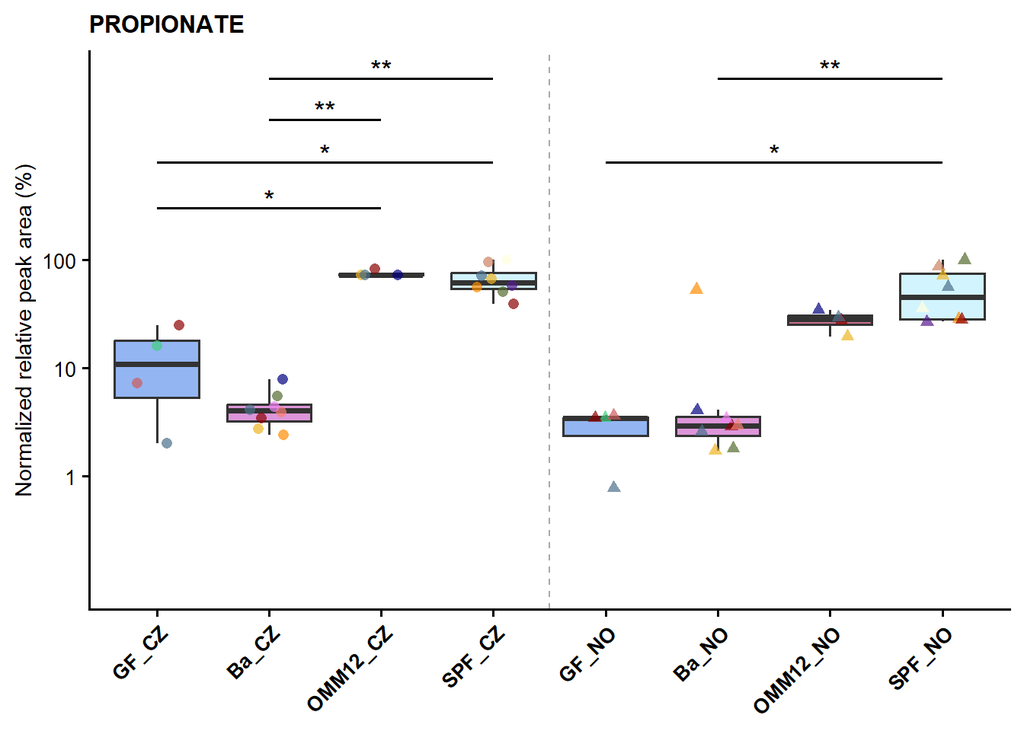

```r
ggplot(propionate, aes(x = COHORT, y = MEDIAN_REL_AREA_NORMALIZED, fill = COHORT)) +
  geom_boxplot(alpha = 0.7, outlier.shape = NA, show.legend = FALSE) +
  geom_vline(xintercept = 4.5, linetype = "dashed", linewidth = 0.5, color = "darkgrey") +
  geom_jitter(aes(color = TYPE, shape = COUNTRY),
              width = 0.2, size = 2, alpha = 0.7, show.legend = FALSE) +
  geom_segment(data = dunn_results_sig,
             aes(x = xmin, xend = xmax, y = y.position, yend = y.position),
             inherit.aes = FALSE) +
  geom_text(data = dunn_results_sig,
          aes(x = (xmin + xmax)/2, y = y.text, label = p.adj.signif),
          inherit.aes = FALSE) +
  scale_color_manual(values = my_palette_color) +
  scale_shape_manual(values = c("CZ" = 16, "NO" = 17)) +
  scale_fill_manual(values = my_palette_fill) +
  scale_y_log10(breaks = c(1,10,100)) +
  coord_cartesian(ylim = c(0.1,5000)) +
  theme_classic(base_size = 14) +
   labs(title = "PROPIONATE", y = "Normalized relative peak area (%)")+
   theme(
    plot.title   = element_text(size = 12, face = "bold"),
    axis.title.x = element_blank(),
    axis.title.y = element_text(size = 11, colour = "black"),
    axis.text.x = element_text(size = 10, face = "bold", angle = 45, hjust = 1, colour = "black"),
    axis.text.y  = element_text(size = 10, colour = "black")
  )
```

Save as a variable

```r
Propionate_boxplots_KW <- ggplot(propionate, aes(x = COHORT, y = MEDIAN_REL_AREA_NORMALIZED, fill = COHORT)) +
  geom_boxplot(alpha = 0.7, outlier.shape = NA, show.legend = FALSE) +
  geom_vline(xintercept = 4.5, linetype = "dashed", linewidth = 0.5, color = "darkgrey") +
  geom_jitter(aes(color = TYPE, shape = COUNTRY),
              width = 0.2, size = 2, alpha = 0.7, show.legend = FALSE) +
  geom_segment(data = dunn_results_sig,
             aes(x = xmin, xend = xmax, y = y.position, yend = y.position),
             inherit.aes = FALSE) +
  geom_text(data = dunn_results_sig,
          aes(x = (xmin + xmax)/2, y = y.text, label = p.adj.signif),
          inherit.aes = FALSE) +
  scale_color_manual(values = my_palette_color) +
  scale_shape_manual(values = c("CZ" = 16, "NO" = 17)) +
  scale_fill_manual(values = my_palette_fill) +
  scale_y_log10(breaks = c(1,10,100)) +
  coord_cartesian(ylim = c(0.1,5000)) +
  theme_classic(base_size = 14) +
   labs(title = "PROPIONATE", y = "Normalized relative peak area (%)")+
   theme(
    plot.title   = element_text(size = 12, face = "bold"),
    axis.title.x = element_blank(),
    axis.title.y = element_text(size = 11, colour = "black"),
    axis.text.x = element_text(size = 10, face = "bold", angle = 45, hjust = 1, colour = "black"),
    axis.text.y  = element_text(size = 10, colour = "black"))
ggsave("Propionate_boxplots_KW.png",
       plot = Propionate_boxplots_KW,
       width = 10, height = 10, dpi = 300)
```

# B U T Y R A T E

Import the dataset and exclude blanks

```r
butyrate <- read_excel("NORWAY_QUANTIFICATION.xlsx", sheet = "NEW_BUTYRATE") %>%
  as.data.frame() %>%
  mutate(`MEDIAN_REL_AREA_NORMALIZED` = as.numeric(`MEDIAN_REL_AREA_NORMALIZED`)) %>%
  filter(COHORT != "Blank")  # Remove rows where COHORT is "Blank"
```

Filter only values Rep1 in the column replicate and exclude samples CV5 and CV6

```r
butyrate <- butyrate %>%
  filter(REPLICATE == "Rep1", !TYPE %in% c("CV5", "CV6"))
```

Define color palette

```r
N <- length(unique(butyrate$TYPE))
my_palette <- viridis(N, option = "A")
desired_order <- c("GF_CZ", "Ba_CZ", "OMM12_CZ", "SPF_CZ", "GF_NO", "Ba_NO" , "OMM12_NO", "SPF_NO")
butyrate$COHORT <- factor(butyrate$COHORT, levels = desired_order)
```

Remove zero or negative values

```r
butyrate <- butyrate %>% filter(`MEDIAN_REL_AREA_NORMALIZED` > 0)
butyrate$COHORT <- factor(butyrate$COHORT, levels = desired_order)
butyrate$TYPE   <- factor(butyrate$TYPE)    # color
levels(butyrate$COHORT)  # should match fill vector length
```

```
## [1] "GF_CZ"    "Ba_CZ"    "OMM12_CZ" "SPF_CZ"   "GF_NO"    "Ba_NO"    "OMM12_NO"
## [8] "SPF_NO"
```

```r
levels(butyrate$TYPE)    # should match color vector length
```

```
##  [1] "368-1" "368-2" "368-3" "368-4" "373-1" "373-2" "373-3" "373-4" "CV1"
## [10] "CV10"  "CV2"   "CV3"   "CV4"   "CV7"   "CV8"   "CV9"   "GF1"   "GF2"
## [19] "GF3"   "GF4"   "OMM1"  "OMM2"  "OMM3"  "OMM4"
```

Are there overall difference among cohorts from CZ dataset?

```r
kruskal.test(MEDIAN_REL_AREA_NORMALIZED ~ COHORT,
             data = subset(butyrate, COUNTRY == "CZ"))
```

```
##
##  Kruskal-Wallis rank sum test
##
## data:  MEDIAN_REL_AREA_NORMALIZED by COHORT
## Kruskal-Wallis chi-squared = 20.108, df = 3, p-value = 0.0001613
```

Are there overall difference among cohorts from NO dataset?

```r
kruskal.test(MEDIAN_REL_AREA_NORMALIZED ~ COHORT,
             data = subset(butyrate, COUNTRY == "NO"))
```

```
##
##  Kruskal-Wallis rank sum test
##
## data:  MEDIAN_REL_AREA_NORMALIZED by COHORT
## Kruskal-Wallis chi-squared = 20.108, df = 3, p-value = 0.0001613
```

Run Dunn test, and only consider differences within CZ or NO data, not mixing them together

```r
dunn_results <- butyrate %>%
 group_by(COUNTRY) %>%
 dunn_test(MEDIAN_REL_AREA_NORMALIZED ~ COHORT,
 p.adjust.method = "BH")
dunn_results
```

```
## # A tibble: 12 × 10
##    COUNTRY .y.               group1 group2    n1    n2 statistic       p   p.adj
##  * <chr>   <chr>             <chr>  <chr>  <int> <int>     <dbl>   <dbl>   <dbl>
##  1 CZ      MEDIAN_REL_AREA_… GF_CZ  Ba_CZ      4     8    -0.953 3.41e-1 3.41e-1
##  2 CZ      MEDIAN_REL_AREA_… GF_CZ  OMM12…     4     4     1.05  2.94e-1 3.41e-1
##  3 CZ      MEDIAN_REL_AREA_… GF_CZ  SPF_CZ     4     8     2.60  9.37e-3 2.81e-2
##  4 CZ      MEDIAN_REL_AREA_… Ba_CZ  OMM12…     8     4     2.17  3.04e-2 6.08e-2
##  5 CZ      MEDIAN_REL_AREA_… Ba_CZ  SPF_CZ     8     8     4.35  1.37e-5 8.22e-5
##  6 CZ      MEDIAN_REL_AREA_… OMM12… SPF_CZ     4     8     1.39  1.66e-1 2.49e-1
##  7 NO      MEDIAN_REL_AREA_… GF_NO  Ba_NO      4     8    -0.953 3.41e-1 3.41e-1
##  8 NO      MEDIAN_REL_AREA_… GF_NO  OMM12…     4     4     1.05  2.94e-1 3.41e-1
##  9 NO      MEDIAN_REL_AREA_… GF_NO  SPF_NO     4     8     2.60  9.37e-3 2.81e-2
## 10 NO      MEDIAN_REL_AREA_… Ba_NO  OMM12…     8     4     2.17  3.04e-2 6.08e-2
## 11 NO      MEDIAN_REL_AREA_… Ba_NO  SPF_NO     8     8     4.35  1.37e-5 8.22e-5
## 12 NO      MEDIAN_REL_AREA_… OMM12… SPF_NO     4     8     1.39  1.66e-1 2.49e-1
## # ℹ 1 more variable: p.adj.signif <chr>
```

Now only select the comparisons where some significance occured

```r
dunn_results_sig <- dunn_results %>%
dplyr::filter(p.adj.signif != "ns")
dunn_results_sig <- dunn_results_sig %>%
mutate(y.position = c(300, 1500, 300, 1500))
dunn_results_sig
```

```
## # A tibble: 4 × 11
##   COUNTRY .y.   group1 group2    n1    n2 statistic       p   p.adj p.adj.signif
##   <chr>   <chr> <chr>  <chr>  <int> <int>     <dbl>   <dbl>   <dbl> <chr>
## 1 CZ      MEDI… GF_CZ  SPF_CZ     4     8      2.60 9.37e-3 2.81e-2 *
## 2 CZ      MEDI… Ba_CZ  SPF_CZ     8     8      4.35 1.37e-5 8.22e-5 ****
## 3 NO      MEDI… GF_NO  SPF_NO     4     8      2.60 9.37e-3 2.81e-2 *
## 4 NO      MEDI… Ba_NO  SPF_NO     8     8      4.35 1.37e-5 8.22e-5 ****
## # ℹ 1 more variable: y.position <dbl>
```

```r
dunn_results_sig$group1
```

```
## [1] "GF_CZ" "Ba_CZ" "GF_NO" "Ba_NO"
```

Create a lookup for x positions

```r
cohort_positions <- data.frame(
  COHORT = levels(factor(butyrate$COHORT,
                         levels = c("GF_CZ","Ba_CZ","OMM12_CZ","SPF_CZ",
                                    "GF_NO","Ba_NO","OMM12_NO","SPF_NO"))),
  x = 1:8)
```

Map x positions

```r
dunn_results_sig <- dunn_results_sig %>%
  left_join(cohort_positions, by = c("group1" = "COHORT")) %>%
  rename(xmin = x) %>%
  left_join(cohort_positions, by = c("group2" = "COHORT")) %>%
  rename(xmax = x) %>%
  mutate(y.position = c(300, 1500, 300, 1500))
dunn_results_sig <- dunn_results_sig %>%
  mutate(y.text = y.position * 1.2)
```

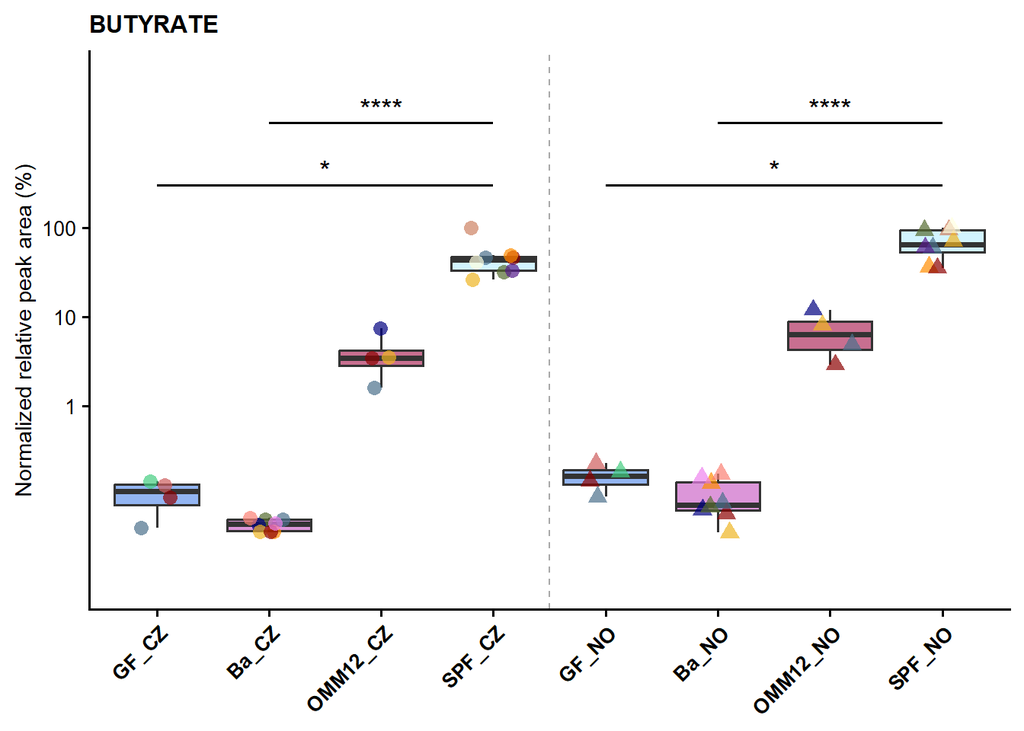

```r
ggplot(butyrate, aes(x = COHORT, y = MEDIAN_REL_AREA_NORMALIZED, fill = COHORT)) +
  geom_boxplot(alpha = 0.7, outlier.shape = NA, show.legend = FALSE) +
  geom_vline(xintercept = 4.5, linetype = "dashed", linewidth = 0.5, color = "darkgrey") +
  geom_jitter(aes(color = TYPE, shape = COUNTRY),
              width = 0.2, size = 3, alpha = 0.7, show.legend = FALSE) +
  geom_segment(data = dunn_results_sig,
               aes(x = xmin, xend = xmax, y = y.position, yend = y.position),
               inherit.aes = FALSE) +
  geom_text(data = dunn_results_sig,
            aes(x = (xmin + xmax)/2, y = y.position, label = p.adj.signif),
            inherit.aes = FALSE, vjust = -0.2) +
  scale_color_manual(values = my_palette_color) +
  scale_shape_manual(values = c("CZ" = 16, "NO" = 17)) +
  scale_fill_manual(values = my_palette_fill) +
  scale_y_log10(breaks = c(1,10,100)) +
  coord_cartesian(ylim = c(0.01,5000)) +
  theme_classic(base_size = 14) +
   labs(title = "BUTYRATE", y = "Normalized relative peak area (%)")+
   theme(
    plot.title   = element_text(size = 12, face = "bold"),
    axis.title.x = element_blank(),
    axis.title.y = element_text(size = 11, colour = "black"),
    axis.text.x = element_text(size = 10, face = "bold", angle = 45, hjust = 1, colour = "black"),
    axis.text.y  = element_text(size = 10, colour = "black")
  )
```

Save as a variable

```r
Butyrate_boxplots_KW <- ggplot(butyrate, aes(x = COHORT, y = MEDIAN_REL_AREA_NORMALIZED, fill = COHORT)) +
  geom_boxplot(alpha = 0.7, outlier.shape = NA, show.legend = FALSE) +
  geom_vline(xintercept = 4.5, linetype = "dashed", linewidth = 0.5, color = "darkgrey") +
  geom_jitter(aes(color = TYPE, shape = COUNTRY),
              width = 0.2, size = 2, alpha = 0.7, show.legend = FALSE) +
  geom_segment(data = dunn_results_sig,
             aes(x = xmin, xend = xmax, y = y.position, yend = y.position),
             inherit.aes = FALSE) +
  geom_text(data = dunn_results_sig,
          aes(x = (xmin + xmax)/2, y = y.text, label = p.adj.signif),
          inherit.aes = FALSE) +
  scale_color_manual(values = my_palette_color) +
  scale_shape_manual(values = c("CZ" = 16, "NO" = 17)) +
  scale_fill_manual(values = my_palette_fill) +
  scale_y_log10(breaks = c(1,10,100)) +
  coord_cartesian(ylim = c(0.03,5000)) +
  theme_classic(base_size = 14) +
   labs(title = "BUTYRATE", y = "Normalized relative peak area (%)")+
   theme(
    plot.title   = element_text(size = 12, face = "bold"),
    axis.title.x = element_blank(),
    axis.title.y = element_text(size = 11, colour = "black"),
    axis.text.x = element_text(size = 10, face = "bold", angle = 45, hjust = 1, colour = "black"),
    axis.text.y  = element_text(size = 10, colour = "black"))
ggsave("Buryrate_boxplots_KW.png",
       plot = Butyrate_boxplots_KW,
       width = 10, height = 10, dpi = 300)
```

# I S O B U T Y R A T E

Import the dataset and exclude blanks

```r
isobutyrate <- read_excel("NORWAY_QUANTIFICATION.xlsx", sheet = "NEW_ISOBUTYRATE") %>%
  as.data.frame() %>%
  mutate(`MEDIAN_REL_AREA_NORMALIZED` = as.numeric(`MEDIAN_REL_AREA_NORMALIZED`)) %>%
  filter(COHORT != "Blank")  # Remove rows where COHORT is "Blank"
```

Filter only values Rep1 in the column replicate and exclude samples CV5 and CV6

```r
isobutyrate <- isobutyrate %>%
  filter(REPLICATE == "Rep1", !TYPE %in% c("CV5", "CV6"))
```

Define color palette

```r
N <- length(unique(isobutyrate$TYPE))
my_palette <- viridis(N, option = "A")
desired_order <- c("GF_CZ", "Ba_CZ", "OMM12_CZ", "SPF_CZ", "GF_NO", "Ba_NO" , "OMM12_NO", "SPF_NO")
isobutyrate$COHORT <- factor(isobutyrate$COHORT, levels = desired_order)
```

Remove zero or negative values

```r
isobutyrate <- isobutyrate %>% filter(`MEDIAN_REL_AREA_NORMALIZED` > 0)
isobutyrate$COHORT <- factor(isobutyrate$COHORT, levels = desired_order)
isobutyrate$TYPE   <- factor(isobutyrate$TYPE)    # color
levels(isobutyrate$COHORT)  # should match fill vector length
```

```
## [1] "GF_CZ"    "Ba_CZ"    "OMM12_CZ" "SPF_CZ"   "GF_NO"    "Ba_NO"    "OMM12_NO"
## [8] "SPF_NO"
```

```r
levels(isobutyrate$TYPE)    # should match color vector length
```

```
##  [1] "368-1" "368-2" "368-3" "368-4" "373-1" "373-2" "373-3" "373-4" "CV1"
## [10] "CV10"  "CV2"   "CV3"   "CV4"   "CV7"   "CV8"   "CV9"   "GF1"   "GF2"
## [19] "GF3"   "GF4"   "OMM1"  "OMM2"  "OMM3"  "OMM4"
```

Are there overall difference among cohorts from CZ dataset?

```r
kruskal.test(MEDIAN_REL_AREA_NORMALIZED ~ COHORT,
             data = subset(isobutyrate, COUNTRY == "CZ"))
```

```
##
##  Kruskal-Wallis rank sum test
##
## data:  MEDIAN_REL_AREA_NORMALIZED by COHORT
## Kruskal-Wallis chi-squared = 19.567, df = 3, p-value = 0.0002086
```

Are there overall difference among cohorts from NO dataset?

```r
kruskal.test(MEDIAN_REL_AREA_NORMALIZED ~ COHORT,
             data = subset(isobutyrate, COUNTRY == "NO"))
```

```
##
##  Kruskal-Wallis rank sum test
##
## data:  MEDIAN_REL_AREA_NORMALIZED by COHORT
## Kruskal-Wallis chi-squared = 19.32, df = 3, p-value = 0.0002348
```

Run Dunn test, and only consider differences within CZ or NO data, not mixing them together

```r
dunn_results <- isobutyrate %>%
 group_by(COUNTRY) %>%
 dunn_test(MEDIAN_REL_AREA_NORMALIZED ~ COHORT,
 p.adjust.method = "BH")
dunn_results
```

```
## # A tibble: 12 × 10
##    COUNTRY .y.               group1 group2    n1    n2 statistic       p   p.adj
##  * <chr>   <chr>             <chr>  <chr>  <int> <int>     <dbl>   <dbl>   <dbl>
##  1 CZ      MEDIAN_REL_AREA_… GF_CZ  Ba_CZ      4     8    -0.606 5.44e-1 5.44e-1
##  2 CZ      MEDIAN_REL_AREA_… GF_CZ  OMM12…     4     4     1.25  2.11e-1 2.54e-1
##  3 CZ      MEDIAN_REL_AREA_… GF_CZ  SPF_CZ     4     8     2.83  4.67e-3 1.40e-2
##  4 CZ      MEDIAN_REL_AREA_… Ba_CZ  OMM12…     8     4     2.05  4.04e-2 8.08e-2
##  5 CZ      MEDIAN_REL_AREA_… Ba_CZ  SPF_CZ     8     8     4.21  2.58e-5 1.55e-4
##  6 CZ      MEDIAN_REL_AREA_… OMM12… SPF_CZ     4     8     1.39  1.66e-1 2.49e-1
##  7 NO      MEDIAN_REL_AREA_… GF_NO  Ba_NO      4     8    -0.346 7.29e-1 7.29e-1
##  8 NO      MEDIAN_REL_AREA_… GF_NO  OMM12…     4     4     1.4   1.62e-1 1.99e-1
##  9 NO      MEDIAN_REL_AREA_… GF_NO  SPF_NO     4     8     3.00  2.68e-3 8.04e-3
## 10 NO      MEDIAN_REL_AREA_… Ba_NO  OMM12…     8     4     1.96  4.96e-2 9.93e-2
## 11 NO      MEDIAN_REL_AREA_… Ba_NO  SPF_NO     8     8     4.10  4.11e-5 2.47e-4
## 12 NO      MEDIAN_REL_AREA_… OMM12… SPF_NO     4     8     1.39  1.66e-1 1.99e-1
## # ℹ 1 more variable: p.adj.signif <chr>
```

Now only select the comparisons where some significance occured

```r
dunn_results_sig <- dunn_results %>%
dplyr::filter(p.adj.signif != "ns")
dunn_results_sig <- dunn_results_sig %>%
mutate(y.position = c(300, 1500, 300, 1500))
dunn_results_sig
```

```
## # A tibble: 4 × 11
##   COUNTRY .y.   group1 group2    n1    n2 statistic       p   p.adj p.adj.signif
##   <chr>   <chr> <chr>  <chr>  <int> <int>     <dbl>   <dbl>   <dbl> <chr>
## 1 CZ      MEDI… GF_CZ  SPF_CZ     4     8      2.83 4.67e-3 1.40e-2 *
## 2 CZ      MEDI… Ba_CZ  SPF_CZ     8     8      4.21 2.58e-5 1.55e-4 ***
## 3 NO      MEDI… GF_NO  SPF_NO     4     8      3.00 2.68e-3 8.04e-3 **
## 4 NO      MEDI… Ba_NO  SPF_NO     8     8      4.10 4.11e-5 2.47e-4 ***
## # ℹ 1 more variable: y.position <dbl>
```

```r
dunn_results_sig$group1
```

```
## [1] "GF_CZ" "Ba_CZ" "GF_NO" "Ba_NO"
```

Create a lookup for x positions

```r
cohort_positions <- data.frame(
  COHORT = levels(factor(isobutyrate$COHORT,
                         levels = c("GF_CZ","Ba_CZ","OMM12_CZ","SPF_CZ",
                                    "GF_NO","Ba_NO","OMM12_NO","SPF_NO"))),
  x = 1:8)
```

Map x positions

```r
dunn_results_sig <- dunn_results_sig %>%
  left_join(cohort_positions, by = c("group1" = "COHORT")) %>%
  rename(xmin = x) %>%
  left_join(cohort_positions, by = c("group2" = "COHORT")) %>%
  rename(xmax = x) %>%
  mutate(y.position = c(300, 1500, 300, 1500))
dunn_results_sig <- dunn_results_sig %>%
  mutate(y.text = y.position * 1.2)
```

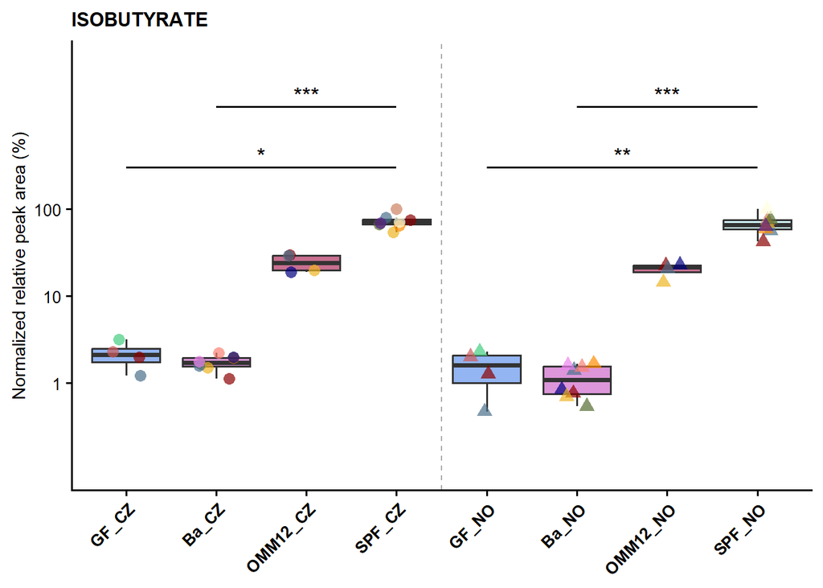

```r
ggplot(isobutyrate, aes(x = COHORT, y = MEDIAN_REL_AREA_NORMALIZED, fill = COHORT)) +
  geom_boxplot(alpha = 0.7, outlier.shape = NA, show.legend = FALSE) +
  geom_vline(xintercept = 4.5, linetype = "dashed", linewidth = 0.5, color = "darkgrey") +
  geom_jitter(aes(color = TYPE, shape = COUNTRY),
              width = 0.2, size = 3, alpha = 0.7, show.legend = FALSE) +
  geom_segment(data = dunn_results_sig,
               aes(x = xmin, xend = xmax, y = y.position, yend = y.position),
               inherit.aes = FALSE) +
  geom_text(data = dunn_results_sig,
            aes(x = (xmin + xmax)/2, y = y.position, label = p.adj.signif),
            inherit.aes = FALSE, vjust = -0.2) +
  scale_color_manual(values = my_palette_color) +
  scale_shape_manual(values = c("CZ" = 16, "NO" = 17)) +
  scale_fill_manual(values = my_palette_fill) +
  scale_y_log10(breaks = c(0,1,10,100)) +
  coord_cartesian(ylim = c(0.1,5000)) +
  theme_classic(base_size = 14) +
   labs(title = "ISOBUTYRATE", y = "Normalized relative peak area (%)")+
   theme(
    plot.title   = element_text(size = 12, face = "bold"),
    axis.title.x = element_blank(),
    axis.title.y = element_text(size = 11, colour = "black"),
    axis.text.x = element_text(size = 10, face = "bold", angle = 45, hjust = 1, colour = "black"),
    axis.text.y  = element_text(size = 10, colour = "black")
  )
```

Save as a variable

```r
Isobutyrate_boxplots_KW <- ggplot(isobutyrate, aes(x = COHORT, y = MEDIAN_REL_AREA_NORMALIZED, fill = COHORT)) +
  geom_boxplot(alpha = 0.7, outlier.shape = NA, show.legend = FALSE) +
  geom_vline(xintercept = 4.5, linetype = "dashed", linewidth = 0.5, color = "darkgrey") +
  geom_jitter(aes(color = TYPE, shape = COUNTRY),
              width = 0.2, size = 2, alpha = 0.7, show.legend = FALSE) +
  geom_segment(data = dunn_results_sig,
             aes(x = xmin, xend = xmax, y = y.position, yend = y.position),
             inherit.aes = FALSE) +
  geom_text(data = dunn_results_sig,
          aes(x = (xmin + xmax)/2, y = y.text, label = p.adj.signif),
          inherit.aes = FALSE) +
  scale_color_manual(values = my_palette_color) +
  scale_shape_manual(values = c("CZ" = 16, "NO" = 17)) +
  scale_fill_manual(values = my_palette_fill) +
  scale_y_log10(breaks = c(1,10,100)) +
  coord_cartesian(ylim = c(0.1,5000)) +
  theme_classic(base_size = 14) +
   labs(title = "ISOBUTYRATE", y = "Normalized relative peak area (%)")+
   theme(
    plot.title   = element_text(size = 12, face = "bold"),
    axis.title.x = element_blank(),
    axis.title.y = element_text(size = 11, colour = "black"),
    axis.text.x = element_text(size = 10, face = "bold", angle = 45, hjust = 1, colour = "black"),
    axis.text.y  = element_text(size = 10, colour = "black"))
ggsave("Isobutyrate_boxplots_KW.png",
       plot = Isobutyrate_boxplots_KW,
       width = 10, height = 10, dpi = 300)
```

# V A L E R A T E

Import the dataset and exclude blanks

```r
valerate <- read_excel("NORWAY_QUANTIFICATION.xlsx", sheet = "NEW_VALERATE") %>%
  as.data.frame() %>%
  mutate(`MEDIAN_REL_AREA_NORMALIZED` = as.numeric(`MEDIAN_REL_AREA_NORMALIZED`)) %>%
  filter(COHORT != "Blank")  # Remove rows where COHORT is "Blank"
```

Filter only values Rep1 in the column replicate and exclude samples CV5 and CV6

```r
valerate <- valerate %>%
  filter(REPLICATE == "Rep1", !TYPE %in% c("CV5", "CV6"))
```

Define color palette

```r
N <- length(unique(valerate$TYPE))
my_palette <- viridis(N, option = "A")
desired_order <- c("GF_CZ", "Ba_CZ", "OMM12_CZ", "SPF_CZ", "GF_NO", "Ba_NO" , "OMM12_NO", "SPF_NO")
valerate$COHORT <- factor(valerate$COHORT, levels = desired_order)
```

Remove zero or negative values

```r
valerate <- valerate %>% filter(`MEDIAN_REL_AREA_NORMALIZED` > 0)
valerate$COHORT <- factor(valerate$COHORT, levels = desired_order)
valerate$TYPE   <- factor(valerate$TYPE)    # color
levels(valerate$COHORT)  # should match fill vector length
```

```
## [1] "GF_CZ"    "Ba_CZ"    "OMM12_CZ" "SPF_CZ"   "GF_NO"    "Ba_NO"    "OMM12_NO"
## [8] "SPF_NO"
```

```r
levels(valerate$TYPE)    # should match color vector length
```

```
##  [1] "368-1" "368-2" "368-3" "368-4" "373-1" "373-2" "373-3" "373-4" "CV1"
## [10] "CV10"  "CV2"   "CV3"   "CV4"   "CV7"   "CV8"   "CV9"   "GF1"   "GF2"
## [19] "GF3"   "GF4"   "OMM1"  "OMM2"  "OMM3"  "OMM4"
```

Are there overall difference among cohorts from CZ dataset?

```r
kruskal.test(MEDIAN_REL_AREA_NORMALIZED ~ COHORT,
             data = subset(valerate, COUNTRY == "CZ"))
```

```
##
##  Kruskal-Wallis rank sum test
##
## data:  MEDIAN_REL_AREA_NORMALIZED by COHORT
## Kruskal-Wallis chi-squared = 20.888, df = 3, p-value = 0.0001111
```

Are there overall difference among cohorts from NO dataset?

```r
kruskal.test(MEDIAN_REL_AREA_NORMALIZED ~ COHORT,
             data = subset(valerate, COUNTRY == "NO"))
```

```
##
##  Kruskal-Wallis rank sum test
##
## data:  MEDIAN_REL_AREA_NORMALIZED by COHORT
## Kruskal-Wallis chi-squared = 20.28, df = 3, p-value = 0.0001485
```

Run Dunn test, and only consider differences within CZ or NO data, not mixing them together

```r
dunn_results <- valerate %>%
 group_by(COUNTRY) %>%
 dunn_test(MEDIAN_REL_AREA_NORMALIZED ~ COHORT,
 p.adjust.method = "BH")
dunn_results
```

```
## # A tibble: 12 × 10
##    COUNTRY .y.               group1 group2    n1    n2 statistic       p   p.adj
##  * <chr>   <chr>             <chr>  <chr>  <int> <int>     <dbl>   <dbl>   <dbl>
##  1 CZ      MEDIAN_REL_AREA_… GF_CZ  Ba_CZ      4     8     -1.30 1.94e-1 2.33e-1
##  2 CZ      MEDIAN_REL_AREA_… GF_CZ  OMM12…     4     4      0.85 3.95e-1 3.95e-1
##  3 CZ      MEDIAN_REL_AREA_… GF_CZ  SPF_CZ     4     8      2.37 1.79e-2 4.52e-2
##  4 CZ      MEDIAN_REL_AREA_… Ba_CZ  OMM12…     8     4      2.28 2.26e-2 4.52e-2
##  5 CZ      MEDIAN_REL_AREA_… Ba_CZ  SPF_CZ     8     8      4.49 7.12e-6 4.27e-5
##  6 CZ      MEDIAN_REL_AREA_… OMM12… SPF_CZ     4     8      1.39 1.66e-1 2.33e-1
##  7 NO      MEDIAN_REL_AREA_… GF_NO  Ba_NO      4     8     -1.04 2.99e-1 3.17e-1
##  8 NO      MEDIAN_REL_AREA_… GF_NO  OMM12…     4     4      1    3.17e-1 3.17e-1
##  9 NO      MEDIAN_REL_AREA_… GF_NO  SPF_NO     4     8      2.54 1.11e-2 3.32e-2
## 10 NO      MEDIAN_REL_AREA_… Ba_NO  OMM12…     8     4      2.19 2.82e-2 5.65e-2
## 11 NO      MEDIAN_REL_AREA_… Ba_NO  SPF_NO     8     8      4.38 1.16e-5 6.99e-5
## 12 NO      MEDIAN_REL_AREA_… OMM12… SPF_NO     4     8      1.39 1.66e-1 2.49e-1
## # ℹ 1 more variable: p.adj.signif <chr>
```

Now only select the comparisons where some significance occured

```r
dunn_results_sig <- dunn_results %>%
dplyr::filter(p.adj.signif != "ns")
dunn_results_sig <- dunn_results_sig %>%
mutate(y.position = c(300, 800, 3000, 30, 3000))
dunn_results_sig
```

```
## # A tibble: 5 × 11
##   COUNTRY .y.   group1 group2    n1    n2 statistic       p   p.adj p.adj.signif
##   <chr>   <chr> <chr>  <chr>  <int> <int>     <dbl>   <dbl>   <dbl> <chr>
## 1 CZ      MEDI… GF_CZ  SPF_CZ     4     8      2.37 1.79e-2 4.52e-2 *
## 2 CZ      MEDI… Ba_CZ  OMM12…     8     4      2.28 2.26e-2 4.52e-2 *
## 3 CZ      MEDI… Ba_CZ  SPF_CZ     8     8      4.49 7.12e-6 4.27e-5 ****
## 4 NO      MEDI… GF_NO  SPF_NO     4     8      2.54 1.11e-2 3.32e-2 *
## 5 NO      MEDI… Ba_NO  SPF_NO     8     8      4.38 1.16e-5 6.99e-5 ****
## # ℹ 1 more variable: y.position <dbl>
```

```r
dunn_results_sig$group1
```

```
## [1] "GF_CZ" "Ba_CZ" "Ba_CZ" "GF_NO" "Ba_NO"
```

Create a lookup for x positions

```r
cohort_positions <- data.frame(
  COHORT = levels(factor(valerate$COHORT,
                         levels = c("GF_CZ","Ba_CZ","OMM12_CZ","SPF_CZ",
                                    "GF_NO","Ba_NO","OMM12_NO","SPF_NO"))),
  x = 1:8)
```

Map x positions

```r
dunn_results_sig <- dunn_results_sig %>%
  left_join(cohort_positions, by = c("group1" = "COHORT")) %>%
  rename(xmin = x) %>%
  left_join(cohort_positions, by = c("group2" = "COHORT")) %>%
  rename(xmax = x) %>%
  mutate(y.position = c(300, 800, 3000, 300, 3000))
dunn_results_sig <- dunn_results_sig %>%
  mutate(y.text = y.position * 1.2)
```

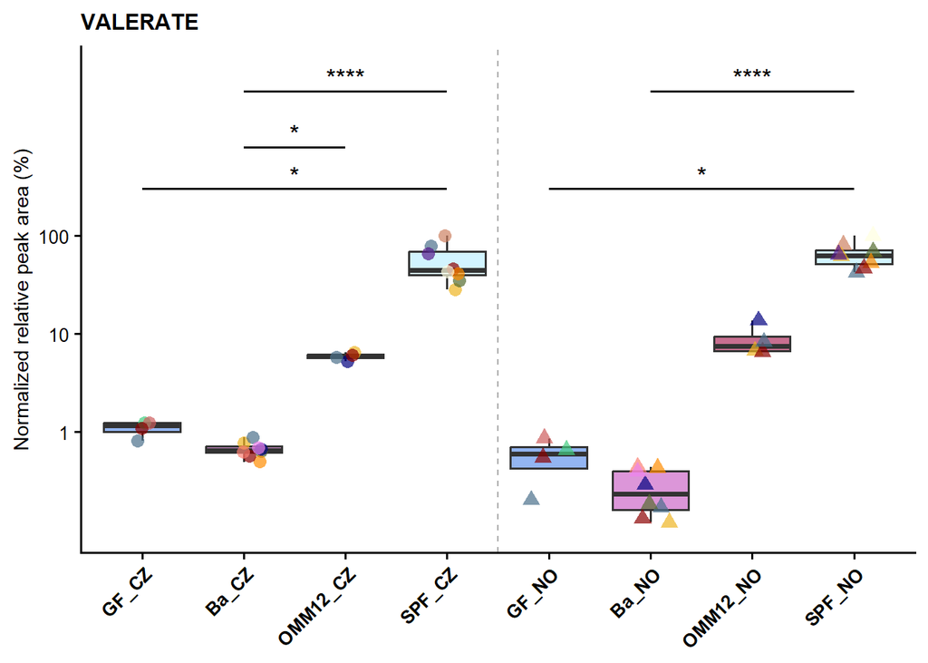

```r
ggplot(valerate, aes(x = COHORT, y = MEDIAN_REL_AREA_NORMALIZED, fill = COHORT)) +
  geom_boxplot(alpha = 0.7, outlier.shape = NA, show.legend = FALSE) +
  geom_vline(xintercept = 4.5, linetype = "dashed", linewidth = 0.5, color = "darkgrey") +
  geom_jitter(aes(color = TYPE, shape = COUNTRY),
              width = 0.2, size = 3, alpha = 0.7, show.legend = FALSE) +
  geom_segment(data = dunn_results_sig,
               aes(x = xmin, xend = xmax, y = y.position, yend = y.position),
               inherit.aes = FALSE) +
  geom_text(data = dunn_results_sig,
            aes(x = (xmin + xmax)/2, y = y.position, label = p.adj.signif),
            inherit.aes = FALSE, vjust = -0.2) +
  scale_color_manual(values = my_palette_color) +
  scale_shape_manual(values = c("CZ" = 16, "NO" = 17)) +
  scale_fill_manual(values = my_palette_fill) +
  scale_y_log10(breaks = c(0,1,10,100)) +
 coord_cartesian(ylim = c(0.1,5000)) +
  theme_classic(base_size = 14) +
   labs(title = "VALERATE", y = "Normalized relative peak area (%)")+
   theme(
    plot.title   = element_text(size = 12, face = "bold"),
    axis.title.x = element_blank(),
    axis.title.y = element_text(size = 11, colour = "black"),
    axis.text.x = element_text(size = 10, face = "bold", angle = 45, hjust = 1, colour = "black"),
    axis.text.y  = element_text(size = 10, colour = "black")
  )
```

Save as a variable

```r
Valerate_boxplots_KW <- ggplot(valerate, aes(x = COHORT, y = MEDIAN_REL_AREA_NORMALIZED, fill = COHORT)) +
  geom_boxplot(alpha = 0.7, outlier.shape = NA, show.legend = FALSE) +
  geom_vline(xintercept = 4.5, linetype = "dashed", linewidth = 0.5, color = "darkgrey") +
  geom_jitter(aes(color = TYPE, shape = COUNTRY),
              width = 0.2, size = 2, alpha = 0.7, show.legend = FALSE) +
  geom_segment(data = dunn_results_sig,
             aes(x = xmin, xend = xmax, y = y.position, yend = y.position),
             inherit.aes = FALSE) +
  geom_text(data = dunn_results_sig,
          aes(x = (xmin + xmax)/2, y = y.text, label = p.adj.signif),
          inherit.aes = FALSE) +
  scale_color_manual(values = my_palette_color) +
  scale_shape_manual(values = c("CZ" = 16, "NO" = 17)) +
  scale_fill_manual(values = my_palette_fill) +
  scale_y_log10(breaks = c(1,10,100)) +
 coord_cartesian(ylim = c(0.1,5000)) +
  theme_classic(base_size = 14) +
   labs(title = "VALERATE", y = "Normalized relative peak area (%)")+
   theme(
    plot.title   = element_text(size = 12, face = "bold"),
    axis.title.x = element_blank(),
    axis.title.y = element_text(size = 11, colour = "black"),
    axis.text.x = element_text(size = 10, face = "bold", angle = 45, hjust = 1, colour = "black"),
    axis.text.y  = element_text(size = 10, colour = "black"))
ggsave("Valerate_boxplots_KW.png",
       plot = Valerate_boxplots_KW,
       width = 10, height = 10, dpi = 300)
```

# I S O V A L E R A T E

Import the dataset and exclude blanks

```r
isovalerate <- read_excel("NORWAY_QUANTIFICATION.xlsx", sheet = "NEW_ISOVALERATE") %>%
  as.data.frame() %>%
  mutate(`MEDIAN_REL_AREA_NORMALIZED` = as.numeric(`MEDIAN_REL_AREA_NORMALIZED`)) %>%
  filter(COHORT != "Blank")  # Remove rows where COHORT is "Blank"
```

Filter only values Rep1 in the column replicate and exclude samples CV5 and CV6

```r
isovalerate <- isovalerate %>%
  filter(REPLICATE == "Rep1", !TYPE %in% c("CV5", "CV6"))
```

Define color palette

```r
N <- length(unique(isovalerate$TYPE))
my_palette <- viridis(N, option = "A")
desired_order <- c("GF_CZ", "Ba_CZ", "OMM12_CZ", "SPF_CZ", "GF_NO", "Ba_NO" , "OMM12_NO", "SPF_NO")
isovalerate$COHORT <- factor(isovalerate$COHORT, levels = desired_order)
```

Remove zero or negative values

```r
isovalerate <- isovalerate %>% filter(`MEDIAN_REL_AREA_NORMALIZED` > 0)
isovalerate$COHORT <- factor(isovalerate$COHORT, levels = desired_order)
isovalerate$TYPE   <- factor(isovalerate$TYPE)    # color
levels(isovalerate$COHORT)  # should match fill vector length
```

```
## [1] "GF_CZ"    "Ba_CZ"    "OMM12_CZ" "SPF_CZ"   "GF_NO"    "Ba_NO"    "OMM12_NO"
## [8] "SPF_NO"
```

```r
levels(isovalerate$TYPE)    # should match color vector length
```

```
##  [1] "368-1" "368-2" "368-3" "368-4" "373-1" "373-2" "373-3" "373-4" "CV1"
## [10] "CV10"  "CV2"   "CV3"   "CV4"   "CV7"   "CV8"   "CV9"   "GF1"   "GF2"
## [19] "GF3"   "GF4"   "OMM1"  "OMM2"  "OMM3"  "OMM4"
```

Are there overall difference among cohorts from CZ dataset?

```r
kruskal.test(MEDIAN_REL_AREA_NORMALIZED ~ COHORT,
             data = subset(isovalerate, COUNTRY == "CZ"))
```

```
##
##  Kruskal-Wallis rank sum test
##
## data:  MEDIAN_REL_AREA_NORMALIZED by COHORT
## Kruskal-Wallis chi-squared = 19.358, df = 3, p-value = 0.0002306
```

Are there overall difference among cohorts from NO dataset?

```r
kruskal.test(MEDIAN_REL_AREA_NORMALIZED ~ COHORT,
             data = subset(isovalerate, COUNTRY == "NO"))
```

```
##
##  Kruskal-Wallis rank sum test
##
## data:  MEDIAN_REL_AREA_NORMALIZED by COHORT
## Kruskal-Wallis chi-squared = 18.48, df = 3, p-value = 0.0003501
```

Run Dunn test, and only consider differences within CZ or NO data, not mixing them together

```r
dunn_results <- isovalerate %>%
 group_by(COUNTRY) %>%
 dunn_test(MEDIAN_REL_AREA_NORMALIZED ~ COHORT,
 p.adjust.method = "BH")
dunn_results
```

```
## # A tibble: 12 × 10
##    COUNTRY .y.               group1 group2    n1    n2 statistic       p   p.adj
##  * <chr>   <chr>             <chr>  <chr>  <int> <int>     <dbl>   <dbl>   <dbl>
##  1 CZ      MEDIAN_REL_AREA_… GF_CZ  Ba_CZ      4     8    -0.779 4.36e-1 4.36e-1
##  2 CZ      MEDIAN_REL_AREA_… GF_CZ  OMM12…     4     4     1.25  2.11e-1 2.70e-1
##  3 CZ      MEDIAN_REL_AREA_… GF_CZ  SPF_CZ     4     8     2.66  7.91e-3 2.37e-2
##  4 CZ      MEDIAN_REL_AREA_… Ba_CZ  OMM12…     8     4     2.22  2.62e-2 5.25e-2
##  5 CZ      MEDIAN_REL_AREA_… Ba_CZ  SPF_CZ     8     8     4.21  2.58e-5 1.55e-4
##  6 CZ      MEDIAN_REL_AREA_… OMM12… SPF_CZ     4     8     1.21  2.25e-1 2.70e-1
##  7 NO      MEDIAN_REL_AREA_… GF_NO  Ba_NO      4     8    -0.346 7.29e-1 7.29e-1
##  8 NO      MEDIAN_REL_AREA_… GF_NO  OMM12…     4     4     1.6   1.10e-1 1.64e-1
##  9 NO      MEDIAN_REL_AREA_… GF_NO  SPF_NO     4     8     2.89  3.89e-3 1.17e-2
## 10 NO      MEDIAN_REL_AREA_… Ba_NO  OMM12…     8     4     2.19  2.82e-2 5.65e-2
## 11 NO      MEDIAN_REL_AREA_… Ba_NO  SPF_NO     8     8     3.96  7.50e-5 4.50e-4
## 12 NO      MEDIAN_REL_AREA_… OMM12… SPF_NO     4     8     1.04  2.99e-1 3.58e-1
## # ℹ 1 more variable: p.adj.signif <chr>
```

Now only select the comparisons where some significance occured

```r
dunn_results_sig <- dunn_results %>%
dplyr::filter(p.adj.signif != "ns")
dunn_results_sig <- dunn_results_sig %>%
mutate(y.position = c(300, 1500, 300, 1500))
dunn_results_sig
```

```
## # A tibble: 4 × 11
##   COUNTRY .y.   group1 group2    n1    n2 statistic       p   p.adj p.adj.signif
##   <chr>   <chr> <chr>  <chr>  <int> <int>     <dbl>   <dbl>   <dbl> <chr>
## 1 CZ      MEDI… GF_CZ  SPF_CZ     4     8      2.66 7.91e-3 2.37e-2 *
## 2 CZ      MEDI… Ba_CZ  SPF_CZ     8     8      4.21 2.58e-5 1.55e-4 ***
## 3 NO      MEDI… GF_NO  SPF_NO     4     8      2.89 3.89e-3 1.17e-2 *
## 4 NO      MEDI… Ba_NO  SPF_NO     8     8      3.96 7.50e-5 4.50e-4 ***
## # ℹ 1 more variable: y.position <dbl>
```

```r
dunn_results_sig$group1
```

```
## [1] "GF_CZ" "Ba_CZ" "GF_NO" "Ba_NO"
```

Create a lookup for x positions

```r
cohort_positions <- data.frame(
  COHORT = levels(factor(isovalerate$COHORT,
                         levels = c("GF_CZ","Ba_CZ","OMM12_CZ","SPF_CZ",
                                    "GF_NO","Ba_NO","OMM12_NO","SPF_NO"))),
  x = 1:8)
```

Map x positions

```r
dunn_results_sig <- dunn_results_sig %>%
  left_join(cohort_positions, by = c("group1" = "COHORT")) %>%
  rename(xmin = x) %>%
  left_join(cohort_positions, by = c("group2" = "COHORT")) %>%
  rename(xmax = x) %>%
  mutate(y.position = c(300, 1500, 300, 1500))
dunn_results_sig <- dunn_results_sig %>%
  mutate(y.text = y.position * 1.2)
```

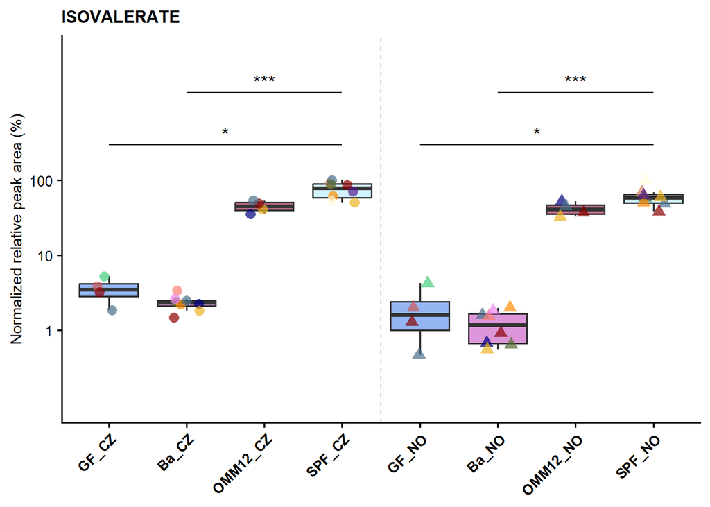

```r
ggplot(isovalerate, aes(x = COHORT, y = MEDIAN_REL_AREA_NORMALIZED, fill = COHORT)) +
  geom_boxplot(alpha = 0.7, outlier.shape = NA, show.legend = FALSE) +
  geom_vline(xintercept = 4.5, linetype = "dashed", linewidth = 0.5, color = "darkgrey") +
  geom_jitter(aes(color = TYPE, shape = COUNTRY),
              width = 0.2, size = 3, alpha = 0.7, show.legend = FALSE) +
  geom_segment(data = dunn_results_sig,
               aes(x = xmin, xend = xmax, y = y.position, yend = y.position),
               inherit.aes = FALSE) +
  geom_text(data = dunn_results_sig,
            aes(x = (xmin + xmax)/2, y = y.position, label = p.adj.signif),
            inherit.aes = FALSE, vjust = -0.2) +
  scale_color_manual(values = my_palette_color) +
  scale_shape_manual(values = c("CZ" = 16, "NO" = 17)) +
  scale_fill_manual(values = my_palette_fill) +
  scale_y_log10(breaks = c(0,1,10,100)) +
 coord_cartesian(ylim = c(0.1,5000)) +
  theme_classic(base_size = 14) +
   labs(title = "ISOVALERATE", y = "Normalized relative peak area (%)")+
   theme(
    plot.title   = element_text(size = 12, face = "bold"),
    axis.title.x = element_blank(),
    axis.title.y = element_text(size = 11, colour = "black"),
    axis.text.x = element_text(size = 10, face = "bold", angle = 45, hjust = 1, colour = "black"),
    axis.text.y  = element_text(size = 10, colour = "black")
  )
```

Save as a variable

```r
Isovalerate_boxplots_KW <- ggplot(isovalerate, aes(x = COHORT, y = MEDIAN_REL_AREA_NORMALIZED, fill = COHORT)) +
  geom_boxplot(alpha = 0.7, outlier.shape = NA, show.legend = FALSE) +
  geom_vline(xintercept = 4.5, linetype = "dashed", linewidth = 0.5, color = "darkgrey") +
  geom_jitter(aes(color = TYPE, shape = COUNTRY),
              width = 0.2, size = 2, alpha = 0.7, show.legend = FALSE) +
  geom_segment(data = dunn_results_sig,
             aes(x = xmin, xend = xmax, y = y.position, yend = y.position),
             inherit.aes = FALSE) +
  geom_text(data = dunn_results_sig,
          aes(x = (xmin + xmax)/2, y = y.text, label = p.adj.signif),
          inherit.aes = FALSE) +
  scale_color_manual(values = my_palette_color) +
  scale_shape_manual(values = c("CZ" = 16, "NO" = 17)) +
  scale_fill_manual(values = my_palette_fill) +
  scale_y_log10(breaks = c(1,10,100)) +
  coord_cartesian(ylim = c(0.1,5000)) +
  theme_classic(base_size = 14) +
   labs(title = "ISOVALERATE/METHYL ISOBUTYRATE", y = "Normalized relative peak area (%)")+
   theme(
    plot.title   = element_text(size = 12, face = "bold"),
    axis.title.x = element_blank(),
    axis.title.y = element_text(size = 11, colour = "black"),
    axis.text.x = element_text(size = 10, face = "bold", angle = 45, hjust = 1, colour = "black"),
    axis.text.y  = element_text(size = 10, colour = "black"))
ggsave("Isovalerate_boxplots_KW.png",
       plot = Isovalerate_boxplots_KW,
       width = 10, height = 10, dpi = 300)
```

# P I V A L A T E

Import the dataset and exclude blanks

```r
pivalate <- read_excel("NORWAY_QUANTIFICATION.xlsx", sheet = "NEW_PIVALATE") %>%
  as.data.frame() %>%
  mutate(`MEDIAN_REL_AREA_NORMALIZED` = as.numeric(`MEDIAN_REL_AREA_NORMALIZED`)) %>%
  filter(COHORT != "Blank")  # Remove rows where COHORT is "Blank"
```

Filter only values Rep1 in the column replicate and exclude samples CV5 and CV6

```r
pivalate <- pivalate %>%
  filter(REPLICATE == "Rep1", !TYPE %in% c("CV5", "CV6"))
```

Define color palette

```r
N <- length(unique(pivalate$TYPE))
my_palette <- viridis(N, option = "A")
desired_order <- c("GF_CZ", "Ba_CZ", "OMM12_CZ", "SPF_CZ", "GF_NO", "Ba_NO" , "OMM12_NO", "SPF_NO")
pivalate$COHORT <- factor(pivalate$COHORT, levels = desired_order)
```

Remove zero or negative values

```r
pivalate <- pivalate %>% filter(`MEDIAN_REL_AREA_NORMALIZED` > 0)
pivalate$COHORT <- factor(pivalate$COHORT, levels = desired_order)
pivalate$TYPE   <- factor(pivalate$TYPE)    # color
levels(pivalate$COHORT)  # should match fill vector length
```

```
## [1] "GF_CZ"    "Ba_CZ"    "OMM12_CZ" "SPF_CZ"   "GF_NO"    "Ba_NO"    "OMM12_NO"
## [8] "SPF_NO"
```

```r
levels(pivalate$TYPE)    # should match color vector length
```

```
##  [1] "368-1" "368-2" "368-3" "368-4" "373-1" "373-2" "373-3" "373-4" "CV1"
## [10] "CV10"  "CV2"   "CV3"   "CV4"   "CV7"   "CV8"   "CV9"   "GF1"   "GF2"
## [19] "GF3"   "GF4"   "OMM1"  "OMM2"  "OMM3"  "OMM4"
```

Are there overall difference among cohorts from CZ dataset?

```r
kruskal.test(MEDIAN_REL_AREA_NORMALIZED ~ COHORT,
             data = subset(pivalate, COUNTRY == "CZ"))
```

```
##
##  Kruskal-Wallis rank sum test
##
## data:  MEDIAN_REL_AREA_NORMALIZED by COHORT
## Kruskal-Wallis chi-squared = 19.567, df = 3, p-value = 0.0002086
```

Are there overall difference among cohorts from NO dataset?

```r
kruskal.test(MEDIAN_REL_AREA_NORMALIZED ~ COHORT,
             data = subset(pivalate, COUNTRY == "NO"))
```

```
##
##  Kruskal-Wallis rank sum test
##
## data:  MEDIAN_REL_AREA_NORMALIZED by COHORT
## Kruskal-Wallis chi-squared = 18.836, df = 3, p-value = 0.0002956
```

Run Dunn test, and only consider differences within CZ or NO data, not mixing them together

```r
dunn_results <- pivalate %>%
 group_by(COUNTRY) %>%
 dunn_test(MEDIAN_REL_AREA_NORMALIZED ~ COHORT,
 p.adjust.method = "BH")
dunn_results
```

```
## # A tibble: 12 × 10
##    COUNTRY .y.               group1 group2    n1    n2 statistic       p   p.adj
##  * <chr>   <chr>             <chr>  <chr>  <int> <int>     <dbl>   <dbl>   <dbl>
##  1 CZ      MEDIAN_REL_AREA_… GF_CZ  Ba_CZ      4     8    -0.606 5.44e-1 5.44e-1
##  2 CZ      MEDIAN_REL_AREA_… GF_CZ  OMM12…     4     4     1.25  2.11e-1 2.54e-1
##  3 CZ      MEDIAN_REL_AREA_… GF_CZ  SPF_CZ     4     8     2.83  4.67e-3 1.40e-2
##  4 CZ      MEDIAN_REL_AREA_… Ba_CZ  OMM12…     8     4     2.05  4.04e-2 8.08e-2
##  5 CZ      MEDIAN_REL_AREA_… Ba_CZ  SPF_CZ     8     8     4.21  2.58e-5 1.55e-4
##  6 CZ      MEDIAN_REL_AREA_… OMM12… SPF_CZ     4     8     1.39  1.66e-1 2.49e-1
##  7 NO      MEDIAN_REL_AREA_… GF_NO  Ba_NO      3     8    -0.499 6.18e-1 6.18e-1
##  8 NO      MEDIAN_REL_AREA_… GF_NO  OMM12…     3     4     1.13  2.60e-1 3.12e-1
##  9 NO      MEDIAN_REL_AREA_… GF_NO  SPF_NO     3     8     2.58  9.96e-3 2.99e-2
## 10 NO      MEDIAN_REL_AREA_… Ba_NO  OMM12…     8     4     1.96  5.04e-2 1.01e-1
## 11 NO      MEDIAN_REL_AREA_… Ba_NO  SPF_NO     8     8     4.17  3.11e-5 1.87e-4
## 12 NO      MEDIAN_REL_AREA_… OMM12… SPF_NO     4     8     1.44  1.49e-1 2.23e-1
## # ℹ 1 more variable: p.adj.signif <chr>
```

Now only select the comparisons where some significance occured

```r
dunn_results_sig <- dunn_results %>%
dplyr::filter(p.adj.signif != "ns")
dunn_results_sig <- dunn_results_sig %>%
mutate(y.position = c(300, 1500, 300, 1500))
dunn_results_sig
```

```
## # A tibble: 4 × 11
##   COUNTRY .y.   group1 group2    n1    n2 statistic       p   p.adj p.adj.signif
##   <chr>   <chr> <chr>  <chr>  <int> <int>     <dbl>   <dbl>   <dbl> <chr>
## 1 CZ      MEDI… GF_CZ  SPF_CZ     4     8      2.83 4.67e-3 1.40e-2 *
## 2 CZ      MEDI… Ba_CZ  SPF_CZ     8     8      4.21 2.58e-5 1.55e-4 ***
## 3 NO      MEDI… GF_NO  SPF_NO     3     8      2.58 9.96e-3 2.99e-2 *
## 4 NO      MEDI… Ba_NO  SPF_NO     8     8      4.17 3.11e-5 1.87e-4 ***
## # ℹ 1 more variable: y.position <dbl>
```

```r
dunn_results_sig$group1
```

```
## [1] "GF_CZ" "Ba_CZ" "GF_NO" "Ba_NO"
```

Create a lookup for x positions

```r
cohort_positions <- data.frame(
  COHORT = levels(factor(pivalate$COHORT,
                         levels = c("GF_CZ","Ba_CZ","OMM12_CZ","SPF_CZ",
                                    "GF_NO","Ba_NO","OMM12_NO","SPF_NO"))),
  x = 1:8)
```

Map x positions

```r
dunn_results_sig <- dunn_results_sig %>%
  left_join(cohort_positions, by = c("group1" = "COHORT")) %>%
  rename(xmin = x) %>%
  left_join(cohort_positions, by = c("group2" = "COHORT")) %>%
  rename(xmax = x) %>%
  mutate(y.position = c(300, 1500, 300, 1500))
dunn_results_sig <- dunn_results_sig %>%
  mutate(y.text = y.position * 1.2)
```

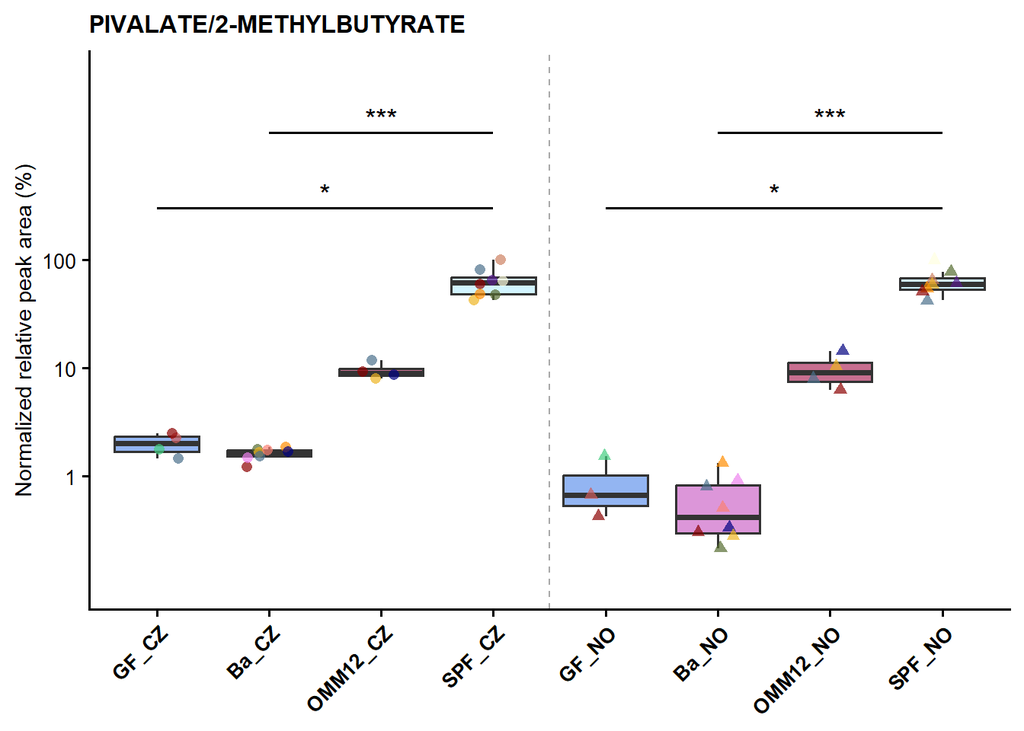

```r
ggplot(pivalate, aes(x = COHORT, y = MEDIAN_REL_AREA_NORMALIZED, fill = COHORT)) +
  geom_boxplot(alpha = 0.7, outlier.shape = NA, show.legend = FALSE) +
  geom_vline(xintercept = 4.5, linetype = "dashed", linewidth = 0.5, color = "darkgrey") +
  geom_jitter(aes(color = TYPE, shape = COUNTRY),
              width = 0.2, size = 2, alpha = 0.7, show.legend = FALSE) +
  geom_segment(data = dunn_results_sig,
               aes(x = xmin, xend = xmax, y = y.position, yend = y.position),
               inherit.aes = FALSE) +
  geom_text(data = dunn_results_sig,
            aes(x = (xmin + xmax)/2, y = y.position, label = p.adj.signif),
            inherit.aes = FALSE, vjust = -0.2) +
  scale_color_manual(values = my_palette_color) +
  scale_shape_manual(values = c("CZ" = 16, "NO" = 17)) +
  scale_fill_manual(values = my_palette_fill) +
  scale_y_log10(breaks = c(0,1,10,100)) +
  coord_cartesian(ylim = c(0.1,5000)) +
  theme_classic(base_size = 14) +
   labs(title = "PIVALATE/2-METHYLBUTYRATE", y = "Normalized relative peak area (%)")+
   theme(
    plot.title   = element_text(size = 12, face = "bold"),
    axis.title.x = element_blank(),
    axis.title.y = element_text(size = 11, colour = "black"),
    axis.text.x = element_text(size = 10, face = "bold", angle = 45, hjust = 1, colour = "black"),
    axis.text.y  = element_text(size = 10, colour = "black")
  )
```

Save as a variable

```r
Pivalate_boxplots_KW <- ggplot(pivalate, aes(x = COHORT, y = MEDIAN_REL_AREA_NORMALIZED, fill = COHORT)) +
  geom_boxplot(alpha = 0.7, outlier.shape = NA, show.legend = FALSE) +
  geom_vline(xintercept = 4.5, linetype = "dashed", linewidth = 0.5, color = "darkgrey") +
  geom_jitter(aes(color = TYPE, shape = COUNTRY),
              width = 0.2, size = 2, alpha = 0.7, show.legend = FALSE) +
  geom_segment(data = dunn_results_sig,
             aes(x = xmin, xend = xmax, y = y.position, yend = y.position),
             inherit.aes = FALSE) +
  geom_text(data = dunn_results_sig,
          aes(x = (xmin + xmax)/2, y = y.text, label = p.adj.signif),
          inherit.aes = FALSE) +
  scale_color_manual(values = my_palette_color) +
  scale_shape_manual(values = c("CZ" = 16, "NO" = 17)) +
  scale_fill_manual(values = my_palette_fill) +
  scale_y_log10(breaks = c(1,10,100)) +
  coord_cartesian(ylim = c(0.1,5000)) +
  theme_classic(base_size = 14) +
   labs(title = "PIVALATE/2-METHYLBUTYRATE", y = "Normalized relative peak area (%)")+
   theme(
    plot.title   = element_text(size = 12, face = "bold"),
    axis.title.x = element_blank(),
    axis.title.y = element_text(size = 11, colour = "black"),
    axis.text.x = element_text(size = 10, face = "bold", angle = 45, hjust = 1, colour = "black"),
    axis.text.y  = element_text(size = 10, colour = "black"))
ggsave("Pivalate_boxplots_KW.png",
       plot = Pivalate_boxplots_KW,
       width = 10, height = 10, dpi = 300)
```

# C I T R A T E

Import the dataset and exclude blanks

```r
citrate <- read_excel("NORWAY_QUANTIFICATION.xlsx", sheet = "NEW_CITRATE") %>%
  as.data.frame() %>%
  mutate(`MEDIAN_REL_AREA_NORMALIZED` = as.numeric(`MEDIAN_REL_AREA_NORMALIZED`)) %>%
  filter(COHORT != "Blank")  # Remove rows where COHORT is "Blank"
```

Filter only values Rep1 in the column replicate and exclude samples CV5 and CV6

```r
citrate <- citrate %>%
  filter(REPLICATE == "Rep1", !TYPE %in% c("CV5", "CV6"))
```

Define color palette

```r
N <- length(unique(citrate$TYPE))
my_palette <- viridis(N, option = "A")
desired_order <- c("GF_CZ", "Ba_CZ", "OMM12_CZ", "SPF_CZ", "GF_NO", "Ba_NO" , "OMM12_NO", "SPF_NO")
citrate$COHORT <- factor(citrate$COHORT, levels = desired_order)
```

Remove zero or negative values

```r
citrate <- citrate %>% filter(`MEDIAN_REL_AREA_NORMALIZED` > 0)
citrate$COHORT <- factor(citrate$COHORT, levels = desired_order)
citrate$TYPE   <- factor(citrate$TYPE)    # color
levels(citrate$COHORT)  # should match fill vector length
```

```
## [1] "GF_CZ"    "Ba_CZ"    "OMM12_CZ" "SPF_CZ"   "GF_NO"    "Ba_NO"    "OMM12_NO"
## [8] "SPF_NO"
```

```r
levels(citrate$TYPE)    # should match color vector length
```

```
##  [1] "368-1" "368-2" "368-3" "368-4" "373-1" "373-2" "373-3" "373-4" "CV1"
## [10] "CV10"  "CV2"   "CV3"   "CV4"   "CV7"   "CV8"   "CV9"   "GF1"   "GF2"
## [19] "GF3"   "GF4"   "OMM1"  "OMM2"  "OMM3"  "OMM4"
```

Are there overall difference among cohorts from CZ dataset?

```r
kruskal.test(MEDIAN_REL_AREA_NORMALIZED ~ COHORT,
             data = subset(citrate, COUNTRY == "CZ"))
```

```
##
##  Kruskal-Wallis rank sum test
##
## data:  MEDIAN_REL_AREA_NORMALIZED by COHORT
## Kruskal-Wallis chi-squared = 13.856, df = 3, p-value = 0.003107
```

Are there overall difference among cohorts from NO dataset?

```r
kruskal.test(MEDIAN_REL_AREA_NORMALIZED ~ COHORT,
             data = subset(citrate, COUNTRY == "NO"))
```

```
##
##  Kruskal-Wallis rank sum test
##
## data:  MEDIAN_REL_AREA_NORMALIZED by COHORT
## Kruskal-Wallis chi-squared = 13.601, df = 3, p-value = 0.003502
```

Run Dunn test, and only consider differences within CZ or NO data, not mixing them together

```r
dunn_results <- citrate %>%
 group_by(COUNTRY) %>%
 dunn_test(MEDIAN_REL_AREA_NORMALIZED ~ COHORT,
 p.adjust.method = "BH")
dunn_results
```

```
## # A tibble: 12 × 10
##    COUNTRY .y.               group1 group2    n1    n2 statistic       p   p.adj
##  * <chr>   <chr>             <chr>  <chr>  <int> <int>     <dbl>   <dbl>   <dbl>
##  1 CZ      MEDIAN_REL_AREA_… GF_CZ  Ba_CZ      4     8    -1.50  1.32e-1 0.199
##  2 CZ      MEDIAN_REL_AREA_… GF_CZ  OMM12…     4     4     0.782 4.34e-1 0.434
##  3 CZ      MEDIAN_REL_AREA_… GF_CZ  SPF_CZ     4     7    -2.50  1.26e-2 0.0321
##  4 CZ      MEDIAN_REL_AREA_… Ba_CZ  OMM12…     8     4     2.41  1.61e-2 0.0321
##  5 CZ      MEDIAN_REL_AREA_… Ba_CZ  SPF_CZ     8     7    -1.24  2.15e-1 0.257
##  6 CZ      MEDIAN_REL_AREA_… OMM12… SPF_CZ     4     7    -3.38  7.32e-4 0.00439
##  7 NO      MEDIAN_REL_AREA_… GF_NO  Ba_NO      4     8    -1.14  2.53e-1 0.303
##  8 NO      MEDIAN_REL_AREA_… GF_NO  OMM12…     4     4     0.209 8.35e-1 0.835
##  9 NO      MEDIAN_REL_AREA_… GF_NO  SPF_NO     4     7    -2.92  3.55e-3 0.0107
## 10 NO      MEDIAN_REL_AREA_… Ba_NO  OMM12…     8     4     1.38  1.66e-1 0.249
## 11 NO      MEDIAN_REL_AREA_… Ba_NO  SPF_NO     8     7    -2.18  2.95e-2 0.0589
## 12 NO      MEDIAN_REL_AREA_… OMM12… SPF_NO     4     7    -3.15  1.63e-3 0.00978
## # ℹ 1 more variable: p.adj.signif <chr>
```

Now only select the comparisons where some significance occured

```r
dunn_results_sig <- dunn_results %>%
dplyr::filter(p.adj.signif != "ns")
dunn_results_sig <- dunn_results_sig %>%
mutate(y.position = c(300, 800, 2500, 300, 2500))
dunn_results_sig
```

```
## # A tibble: 5 × 11
##   COUNTRY .y.   group1 group2    n1    n2 statistic       p   p.adj p.adj.signif
##   <chr>   <chr> <chr>  <chr>  <int> <int>     <dbl>   <dbl>   <dbl> <chr>
## 1 CZ      MEDI… GF_CZ  SPF_CZ     4     7     -2.50 1.26e-2 0.0321  *
## 2 CZ      MEDI… Ba_CZ  OMM12…     8     4      2.41 1.61e-2 0.0321  *
## 3 CZ      MEDI… OMM12… SPF_CZ     4     7     -3.38 7.32e-4 0.00439 **
## 4 NO      MEDI… GF_NO  SPF_NO     4     7     -2.92 3.55e-3 0.0107  *
## 5 NO      MEDI… OMM12… SPF_NO     4     7     -3.15 1.63e-3 0.00978 **
## # ℹ 1 more variable: y.position <dbl>
```

```r
dunn_results_sig$group1
```

```
## [1] "GF_CZ"    "Ba_CZ"    "OMM12_CZ" "GF_NO"    "OMM12_NO"
```

Create a lookup for x positions

```r
cohort_positions <- data.frame(
  COHORT = levels(factor(citrate$COHORT,
                         levels = c("GF_CZ","Ba_CZ","OMM12_CZ","SPF_CZ",
                                    "GF_NO","Ba_NO","OMM12_NO","SPF_NO"))),
  x = 1:8)
```

Map x positions

```r
dunn_results_sig <- dunn_results_sig %>%
  left_join(cohort_positions, by = c("group1" = "COHORT")) %>%
  rename(xmin = x) %>%
  left_join(cohort_positions, by = c("group2" = "COHORT")) %>%
  rename(xmax = x) %>%
  mutate(y.position = c(300, 800, 2500, 300, 2500))
dunn_results_sig <- dunn_results_sig %>%
  mutate(y.text = y.position * 1.2)
```

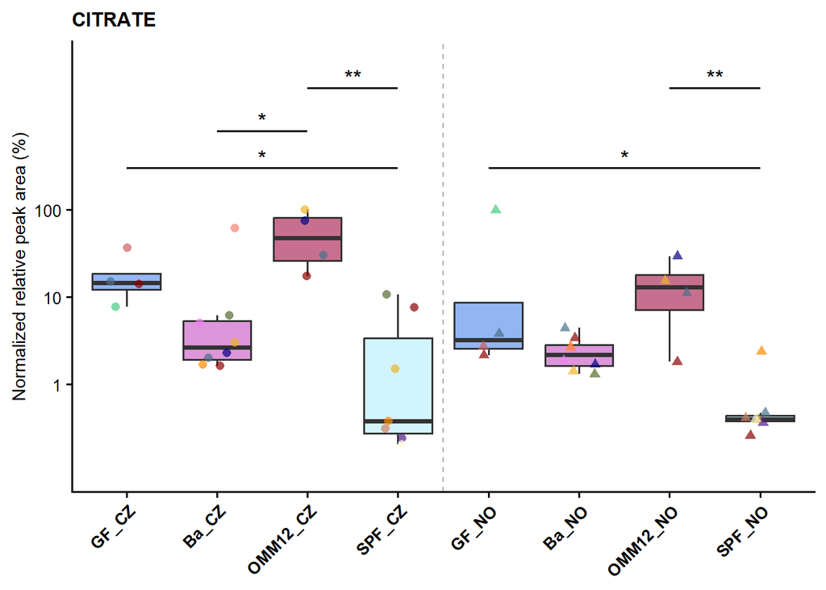

```r
ggplot(citrate, aes(x = COHORT, y = MEDIAN_REL_AREA_NORMALIZED, fill = COHORT)) +
  geom_boxplot(alpha = 0.7, outlier.shape = NA, show.legend = FALSE) +
  geom_vline(xintercept = 4.5, linetype = "dashed", linewidth = 0.5, color = "darkgrey") +
  geom_jitter(aes(color = TYPE, shape = COUNTRY),
              width = 0.2, size = 2, alpha = 0.7, show.legend = FALSE) +
  geom_segment(data = dunn_results_sig,
               aes(x = xmin, xend = xmax, y = y.position, yend = y.position),
               inherit.aes = FALSE) +
  geom_text(data = dunn_results_sig,
            aes(x = (xmin + xmax)/2, y = y.position, label = p.adj.signif),
            inherit.aes = FALSE, vjust = -0.1) +
  scale_color_manual(values = my_palette_color) +
  scale_shape_manual(values = c("CZ" = 16, "NO" = 17)) +
  scale_fill_manual(values = my_palette_fill) +
  scale_y_log10(breaks = c(0,1,10,100)) +
  coord_cartesian(ylim = c(0.1,5000)) +
  theme_classic(base_size = 14) +
   labs(title = "CITRATE", y = "Normalized relative peak area (%)")+
   theme(
    plot.title   = element_text(size = 12, face = "bold"),
    axis.title.x = element_blank(),
    axis.title.y = element_text(size = 11, colour = "black"),
    axis.text.x = element_text(size = 10, face = "bold", angle = 45, hjust = 1, colour = "black"),
    axis.text.y  = element_text(size = 10, colour = "black")
  )
```

Save as a variable

```r
Citrate_boxplots_KW <- ggplot(citrate, aes(x = COHORT, y = MEDIAN_REL_AREA_NORMALIZED, fill = COHORT)) +
  geom_boxplot(alpha = 0.7, outlier.shape = NA, show.legend = FALSE) +
  geom_vline(xintercept = 4.5, linetype = "dashed", linewidth = 0.5, color = "darkgrey") +
  geom_jitter(aes(color = TYPE, shape = COUNTRY),
              width = 0.2, size = 2, alpha = 0.7, show.legend = FALSE) +
  geom_segment(data = dunn_results_sig,
             aes(x = xmin, xend = xmax, y = y.position, yend = y.position),
             inherit.aes = FALSE) +
  geom_text(data = dunn_results_sig,
          aes(x = (xmin + xmax)/2, y = y.text, label = p.adj.signif),
          inherit.aes = FALSE) +
  scale_color_manual(values = my_palette_color) +
  scale_shape_manual(values = c("CZ" = 16, "NO" = 17)) +
  scale_fill_manual(values = my_palette_fill) +
  scale_y_log10(breaks = c(1,10,100)) +
  coord_cartesian(ylim = c(0.1,5000)) +
  theme_classic(base_size = 14) +
   labs(title = "CITRATE", y = "Normalized relative peak area (%)")+
   theme(
    plot.title   = element_text(size = 12, face = "bold"),
    axis.title.x = element_blank(),
    axis.title.y = element_text(size = 11, colour = "black"),
    axis.text.x = element_text(size = 10, face = "bold", angle = 45, hjust = 1, colour = "black"),
    axis.text.y  = element_text(size = 10, colour = "black"))
ggsave("Citrate_boxplots_KW.png",
       plot = Citrate_boxplots_KW,
       width = 10, height = 10, dpi = 300)
```

# M A L A T E

Import the dataset and exclude blanks

```r
malate <- read_excel("NORWAY_QUANTIFICATION.xlsx", sheet = "NEW_MALATE") %>%
  as.data.frame() %>%
  mutate(`conc_mmol/mg` = as.numeric(`conc_mmol/mg`)) %>%
  filter(COHORT != "Blank")  # Remove rows where COHORT is "Blank"
```

Filter only values Rep1 in the column replicate and exclude samples CV5 and CV6

```r
malate <- malate %>%
  filter(REPLICATE == "Rep1", !TYPE %in% c("CV5", "CV6"))
```

Define color palette

```r
N <- length(unique(malate$TYPE))
my_palette <- viridis(N, option = "A")
desired_order <- c("GF_CZ", "Ba_CZ", "OMM12_CZ", "SPF_CZ", "GF_NO", "Ba_NO" , "OMM12_NO", "SPF_NO")
malate$COHORT <- factor(malate$COHORT, levels = desired_order)
```

Remove zero or negative values

```r
malate <- malate %>% filter(`MEDIAN_REL_AREA_NORMALIZED` > 0)
malate$COHORT <- factor(malate$COHORT, levels = desired_order)
malate$TYPE   <- factor(malate$TYPE)    # color
levels(malate$COHORT)  # should match fill vector length
```

```
## [1] "GF_CZ"    "Ba_CZ"    "OMM12_CZ" "SPF_CZ"   "GF_NO"    "Ba_NO"    "OMM12_NO"
## [8] "SPF_NO"
```

```r
levels(malate$TYPE)    # should match color vector length
```

```
##  [1] "368-1" "368-2" "368-3" "368-4" "373-1" "373-2" "373-3" "373-4" "CV1"
## [10] "CV10"  "CV2"   "CV3"   "CV4"   "CV7"   "CV8"   "CV9"   "GF1"   "GF2"
## [19] "GF3"   "GF4"   "OMM1"  "OMM2"  "OMM3"  "OMM4"
```

Are there overall difference among cohorts from CZ dataset?

```r
kruskal.test(MEDIAN_REL_AREA_NORMALIZED ~ COHORT,
             data = subset(malate, COUNTRY == "CZ"))
```

```
##
##  Kruskal-Wallis rank sum test
##
## data:  MEDIAN_REL_AREA_NORMALIZED by COHORT
## Kruskal-Wallis chi-squared = 15.968, df = 3, p-value = 0.001152
```

Are there overall difference among cohorts from NO dataset?

```r
kruskal.test(MEDIAN_REL_AREA_NORMALIZED ~ COHORT,
             data = subset(malate, COUNTRY == "NO"))
```

```
##
##  Kruskal-Wallis rank sum test
##
## data:  MEDIAN_REL_AREA_NORMALIZED by COHORT
## Kruskal-Wallis chi-squared = 13.257, df = 3, p-value = 0.004112
```

Run Dunn test, and only consider differences within CZ or NO data, not mixing them together

```r
dunn_results <- malate %>%
 group_by(COUNTRY) %>%
 dunn_test(MEDIAN_REL_AREA_NORMALIZED ~ COHORT,
 p.adjust.method = "BH")
dunn_results
```

```
## # A tibble: 12 × 10
##    COUNTRY .y.               group1 group2    n1    n2 statistic       p   p.adj
##  * <chr>   <chr>             <chr>  <chr>  <int> <int>     <dbl>   <dbl>   <dbl>
##  1 CZ      MEDIAN_REL_AREA_… GF_CZ  Ba_CZ      4     8    -1.21  2.25e-1 0.260
##  2 CZ      MEDIAN_REL_AREA_… GF_CZ  OMM12…     4     4     2.05  4.04e-2 0.0807
##  3 CZ      MEDIAN_REL_AREA_… GF_CZ  SPF_CZ     4     8     1.24  2.14e-1 0.260
##  4 CZ      MEDIAN_REL_AREA_… Ba_CZ  OMM12…     8     4     3.58  3.44e-4 0.00206
##  5 CZ      MEDIAN_REL_AREA_… Ba_CZ  SPF_CZ     8     8     3.01  2.65e-3 0.00796
##  6 CZ      MEDIAN_REL_AREA_… OMM12… SPF_CZ     4     8    -1.13  2.60e-1 0.260
##  7 NO      MEDIAN_REL_AREA_… GF_NO  Ba_NO      3     8    -2.17  3.01e-2 0.0591
##  8 NO      MEDIAN_REL_AREA_… GF_NO  OMM12…     3     4     0.467 6.41e-1 0.769
##  9 NO      MEDIAN_REL_AREA_… GF_NO  SPF_NO     3     8    -2.06  3.94e-2 0.0591
## 10 NO      MEDIAN_REL_AREA_… Ba_NO  OMM12…     8     4     2.98  2.89e-3 0.0127
## 11 NO      MEDIAN_REL_AREA_… Ba_NO  SPF_NO     8     8     0.147 8.83e-1 0.883
## 12 NO      MEDIAN_REL_AREA_… OMM12… SPF_NO     4     8    -2.86  4.25e-3 0.0127
## # ℹ 1 more variable: p.adj.signif <chr>
```

Now only select the comparisons where some significance occured

```r
dunn_results_sig <- dunn_results %>%
dplyr::filter(p.adj.signif != "ns")
dunn_results_sig <- dunn_results_sig %>%
mutate(y.position = c(300, 800, 150, 2000))
dunn_results_sig
```

```
## # A tibble: 4 × 11
##   COUNTRY .y.   group1 group2    n1    n2 statistic       p   p.adj p.adj.signif
##   <chr>   <chr> <chr>  <chr>  <int> <int>     <dbl>   <dbl>   <dbl> <chr>
## 1 CZ      MEDI… Ba_CZ  OMM12…     8     4      3.58 3.44e-4 0.00206 **
## 2 CZ      MEDI… Ba_CZ  SPF_CZ     8     8      3.01 2.65e-3 0.00796 **
## 3 NO      MEDI… Ba_NO  OMM12…     8     4      2.98 2.89e-3 0.0127  *
## 4 NO      MEDI… OMM12… SPF_NO     4     8     -2.86 4.25e-3 0.0127  *
## # ℹ 1 more variable: y.position <dbl>
```

```r
dunn_results_sig$group1
```

```
## [1] "Ba_CZ"    "Ba_CZ"    "Ba_NO"    "OMM12_NO"
```

Create a lookup for x positions

```r
cohort_positions <- data.frame(
  COHORT = levels(factor(malate$COHORT,
                         levels = c("GF_CZ","Ba_CZ","OMM12_CZ","SPF_CZ",
                                    "GF_NO","Ba_NO","OMM12_NO","SPF_NO"))),
  x = 1:8)
```

Map x positions

```r
dunn_results_sig <- dunn_results_sig %>%
  left_join(cohort_positions, by = c("group1" = "COHORT")) %>%
  rename(xmin = x) %>%
  left_join(cohort_positions, by = c("group2" = "COHORT")) %>%
  rename(xmax = x) %>%
  mutate(y.position = c(300, 800, 150, 2000))
dunn_results_sig <- dunn_results_sig %>%
  mutate(y.text = y.position * 1.2)
```

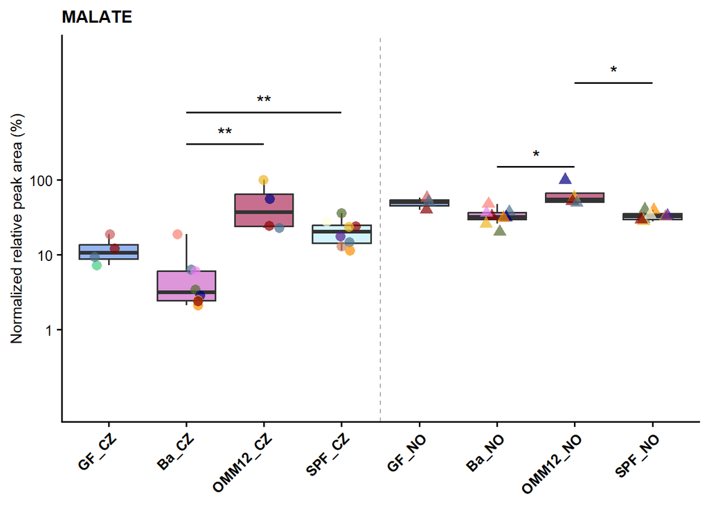

```r
ggplot(malate, aes(x = COHORT, y = MEDIAN_REL_AREA_NORMALIZED, fill = COHORT)) +
  geom_boxplot(alpha = 0.7, outlier.shape = NA, show.legend = FALSE) +
  geom_vline(xintercept = 4.5, linetype = "dashed", linewidth = 0.5, color = "darkgrey") +
  geom_jitter(aes(color = TYPE, shape = COUNTRY),
              width = 0.2, size = 3, alpha = 0.7, show.legend = FALSE) +
  geom_segment(data = dunn_results_sig,
               aes(x = xmin, xend = xmax, y = y.position, yend = y.position),
               inherit.aes = FALSE) +
  geom_text(data = dunn_results_sig,
            aes(x = (xmin + xmax)/2, y = y.position, label = p.adj.signif),
            inherit.aes = FALSE, vjust = -0.2) +
  scale_color_manual(values = my_palette_color) +
  scale_shape_manual(values = c("CZ" = 16, "NO" = 17)) +
  scale_fill_manual(values = my_palette_fill) +
  scale_y_log10(breaks = c(1,10,100)) +
  coord_cartesian(ylim = c(0.1,5000)) +
  theme_classic(base_size = 14) +
   labs(title = "MALATE", y = "Normalized relative peak area (%)")+
   theme(
    plot.title   = element_text(size = 12, face = "bold"),
    axis.title.x = element_blank(),
    axis.title.y = element_text(size = 11, colour = "black"),
    axis.text.x = element_text(size = 10, face = "bold", angle = 45, hjust = 1, colour = "black"),
    axis.text.y  = element_text(size = 10, colour = "black")
  )
```

Save as a variable

```r
Malate_boxplots_KW <- ggplot(malate, aes(x = COHORT, y = MEDIAN_REL_AREA_NORMALIZED, fill = COHORT)) +
  geom_boxplot(alpha = 0.7, outlier.shape = NA, show.legend = FALSE) +
  geom_vline(xintercept = 4.5, linetype = "dashed", linewidth = 0.5, color = "darkgrey") +
  geom_jitter(aes(color = TYPE, shape = COUNTRY),
              width = 0.2, size = 2, alpha = 0.7, show.legend = FALSE) +
  geom_segment(data = dunn_results_sig,
             aes(x = xmin, xend = xmax, y = y.position, yend = y.position),
             inherit.aes = FALSE) +
  geom_text(data = dunn_results_sig,
          aes(x = (xmin + xmax)/2, y = y.text, label = p.adj.signif),
          inherit.aes = FALSE) +
  scale_color_manual(values = my_palette_color) +
  scale_shape_manual(values = c("CZ" = 16, "NO" = 17)) +
  scale_fill_manual(values = my_palette_fill) +
  scale_y_log10(breaks = c(1,10,100)) +
  coord_cartesian(ylim = c(0.1,5000)) +
  theme_classic(base_size = 14) +
   labs(title = "MALATE", y = "Normalized relative peak area (%)")+
   theme(
    plot.title   = element_text(size = 12, face = "bold"),
    axis.title.x = element_blank(),
    axis.title.y = element_text(size = 11, colour = "black"),
    axis.text.x = element_text(size = 10, face = "bold", angle = 45, hjust = 1, colour = "black"),
    axis.text.y  = element_text(size = 10, colour = "black"))
ggsave("MALATE_boxplots_KW.png",
       plot = Malate_boxplots_KW,
       width = 10, height = 10, dpi = 300)
```

# S U C C I N A T E

Import the dataset and exclude blanks

```r
succinate <- read_excel("NORWAY_QUANTIFICATION.xlsx", sheet = "NEW_SUCCINATE") %>%
  as.data.frame() %>%
  mutate(`conc_mmol/mg` = as.numeric(`conc_mmol/mg`)) %>%
  filter(COHORT != "Blank")  # Remove rows where COHORT is "Blank"
```

Filter only values Rep1 in the column replicate and exclude samples CV5 and CV6

```r
succinate <- succinate %>%
  filter(REPLICATE == "Rep1", !TYPE %in% c("CV5", "CV6"))
```

Define color palette

```r
N <- length(unique(succinate$TYPE))
my_palette <- viridis(N, option = "A")
desired_order <- c("GF_CZ", "Ba_CZ", "OMM12_CZ", "SPF_CZ", "GF_NO", "Ba_NO" , "OMM12_NO", "SPF_NO")
succinate$COHORT <- factor(succinate$COHORT, levels = desired_order)
```

Remove zero or negative values

```r
succinate <- succinate %>% filter(`MEDIAN_REL_AREA_NORMALIZED` > 0)
succinate$COHORT <- factor(succinate$COHORT, levels = desired_order)
succinate$TYPE   <- factor(succinate$TYPE)
levels(succinate$COHORT)
```

```
## [1] "GF_CZ"    "Ba_CZ"    "OMM12_CZ" "SPF_CZ"   "GF_NO"    "Ba_NO"    "OMM12_NO"
## [8] "SPF_NO"
```

```r
levels(succinate$TYPE)
```

```
##  [1] "368-1" "368-2" "368-3" "368-4" "373-1" "373-2" "373-3" "373-4" "CV1"
## [10] "CV10"  "CV2"   "CV3"   "CV4"   "CV7"   "CV8"   "CV9"   "GF1"   "GF2"
## [19] "GF3"   "GF4"   "OMM1"  "OMM2"  "OMM3"  "OMM4"
```

Are there overall difference among cohorts from CZ dataset?

```r
kruskal.test(MEDIAN_REL_AREA_NORMALIZED ~ COHORT,
             data = subset(succinate, COUNTRY == "CZ"))
```

```
##
##  Kruskal-Wallis rank sum test
##
## data:  MEDIAN_REL_AREA_NORMALIZED by COHORT
## Kruskal-Wallis chi-squared = 17.79, df = 3, p-value = 0.000486
```

Are there overall difference among cohorts from NO dataset?

```r
kruskal.test(MEDIAN_REL_AREA_NORMALIZED ~ COHORT,
             data = subset(succinate, COUNTRY == "NO"))
```

```
##
##  Kruskal-Wallis rank sum test
##
## data:  MEDIAN_REL_AREA_NORMALIZED by COHORT
## Kruskal-Wallis chi-squared = 9.04, df = 3, p-value = 0.02876
```

Run Dunn test, and only consider differences within CZ or NO data, not mixing them together

```r
dunn_results <- succinate %>%
 group_by(COUNTRY) %>%
 dunn_test(MEDIAN_REL_AREA_NORMALIZED ~ COHORT,
 p.adjust.method = "BH")
dunn_results
```

```
## # A tibble: 12 × 10
##    COUNTRY .y.               group1 group2    n1    n2 statistic       p   p.adj
##  * <chr>   <chr>             <chr>  <chr>  <int> <int>     <dbl>   <dbl>   <dbl>
##  1 CZ      MEDIAN_REL_AREA_… GF_CZ  Ba_CZ      4     8    -0.577 5.64e-1 0.564
##  2 CZ      MEDIAN_REL_AREA_… GF_CZ  OMM12…     4     4     2.5   1.24e-2 0.0248
##  3 CZ      MEDIAN_REL_AREA_… GF_CZ  SPF_CZ     4     8     2.08  3.77e-2 0.0565
##  4 CZ      MEDIAN_REL_AREA_… Ba_CZ  OMM12…     8     4     3.46  5.32e-4 0.00319
##  5 CZ      MEDIAN_REL_AREA_… Ba_CZ  SPF_CZ     8     8     3.25  1.14e-3 0.00343
##  6 CZ      MEDIAN_REL_AREA_… OMM12… SPF_CZ     4     8    -0.808 4.19e-1 0.503
##  7 NO      MEDIAN_REL_AREA_… GF_NO  Ba_NO      4     8    -0.577 5.64e-1 0.806
##  8 NO      MEDIAN_REL_AREA_… GF_NO  OMM12…     4     4     2     4.55e-2 0.0910
##  9 NO      MEDIAN_REL_AREA_… GF_NO  SPF_NO     4     8    -0.231 8.17e-1 0.817
## 10 NO      MEDIAN_REL_AREA_… Ba_NO  OMM12…     8     4     2.89  3.89e-3 0.0234
## 11 NO      MEDIAN_REL_AREA_… Ba_NO  SPF_NO     8     8     0.424 6.71e-1 0.806
## 12 NO      MEDIAN_REL_AREA_… OMM12… SPF_NO     4     8    -2.54  1.11e-2 0.0332
## # ℹ 1 more variable: p.adj.signif <chr>
```

Now only select the comparisons where some significance occured

```r
dunn_results_sig <- dunn_results %>%
dplyr::filter(p.adj.signif != "ns")
dunn_results_sig <- dunn_results_sig %>%
mutate(y.position = c(300, 800, 2000, 800, 4800))
dunn_results_sig
```

```
## # A tibble: 5 × 11
##   COUNTRY .y.   group1 group2    n1    n2 statistic       p   p.adj p.adj.signif
##   <chr>   <chr> <chr>  <chr>  <int> <int>     <dbl>   <dbl>   <dbl> <chr>
## 1 CZ      MEDI… GF_CZ  OMM12…     4     4      2.5  1.24e-2 0.0248  *
## 2 CZ      MEDI… Ba_CZ  OMM12…     8     4      3.46 5.32e-4 0.00319 **
## 3 CZ      MEDI… Ba_CZ  SPF_CZ     8     8      3.25 1.14e-3 0.00343 **
## 4 NO      MEDI… Ba_NO  OMM12…     8     4      2.89 3.89e-3 0.0234  *
## 5 NO      MEDI… OMM12… SPF_NO     4     8     -2.54 1.11e-2 0.0332  *
## # ℹ 1 more variable: y.position <dbl>
```

```r
dunn_results_sig$group1
```

```
## [1] "GF_CZ"    "Ba_CZ"    "Ba_CZ"    "Ba_NO"    "OMM12_NO"
```

Create a lookup for x positions

```r
cohort_positions <- data.frame(
  COHORT = levels(factor(succinate$COHORT,
                         levels = c("GF_CZ","Ba_CZ","OMM12_CZ","SPF_CZ",
                                    "GF_NO","Ba_NO","OMM12_NO","SPF_NO"))),
  x = 1:8)
```

Map x positions

```r
dunn_results_sig <- dunn_results_sig %>%
  left_join(cohort_positions, by = c("group1" = "COHORT")) %>%
  rename(xmin = x) %>%
  left_join(cohort_positions, by = c("group2" = "COHORT")) %>%
  rename(xmax = x) %>%
  mutate(y.position = c(300, 800, 2000, 800, 4800))
dunn_results_sig <- dunn_results_sig %>%
  mutate(y.text = y.position * 1.2)
```

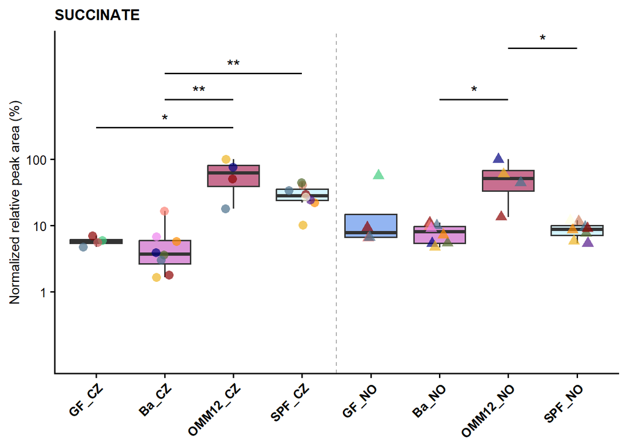

```r
ggplot(succinate, aes(x = COHORT, y = MEDIAN_REL_AREA_NORMALIZED, fill = COHORT)) +
  geom_boxplot(alpha = 0.7, outlier.shape = NA, show.legend = FALSE) +
  geom_vline(xintercept = 4.5, linetype = "dashed", linewidth = 0.5, color = "darkgrey") +
  geom_jitter(aes(color = TYPE, shape = COUNTRY),
              width = 0.2, size = 3, alpha = 0.7, show.legend = FALSE) +
  geom_segment(data = dunn_results_sig,
               aes(x = xmin, xend = xmax, y = y.position, yend = y.position),
               inherit.aes = FALSE) +
  geom_text(data = dunn_results_sig,
            aes(x = (xmin + xmax)/2, y = y.position, label = p.adj.signif),
            inherit.aes = FALSE, vjust = -0.1) +
  scale_color_manual(values = my_palette_color) +
  scale_shape_manual(values = c("CZ" = 16, "NO" = 17)) +
  scale_fill_manual(values = my_palette_fill) +
  scale_y_log10(breaks = c(1,10,100)) +
 coord_cartesian(ylim = c(0.1,5000)) +
  theme_classic(base_size = 14) +
   labs(title = "SUCCINATE", y = "Normalized relative peak area (%)")+
   theme(
    plot.title   = element_text(size = 12, face = "bold"),
    axis.title.x = element_blank(),
    axis.title.y = element_text(size = 11, colour = "black"),
    axis.text.x = element_text(size = 10, face = "bold", angle = 45, hjust = 1, colour = "black"),
    axis.text.y  = element_text(size = 10, colour = "black")
  )
```

Save as a variable

```r
Succinate_boxplots_KW <- ggplot(succinate, aes(x = COHORT, y = MEDIAN_REL_AREA_NORMALIZED, fill = COHORT)) +
  geom_boxplot(alpha = 0.7, outlier.shape = NA, show.legend = FALSE) +
  geom_vline(xintercept = 4.5, linetype = "dashed", linewidth = 0.5, color = "darkgrey") +
  geom_jitter(aes(color = TYPE, shape = COUNTRY),
              width = 0.2, size = 2, alpha = 0.7, show.legend = FALSE) +
  geom_segment(data = dunn_results_sig,
             aes(x = xmin, xend = xmax, y = y.position, yend = y.position),
             inherit.aes = FALSE) +
  geom_text(data = dunn_results_sig,
          aes(x = (xmin + xmax)/2, y = y.text, label = p.adj.signif),
          inherit.aes = FALSE) +
  scale_color_manual(values = my_palette_color) +
  scale_shape_manual(values = c("CZ" = 16, "NO" = 17)) +
  scale_fill_manual(values = my_palette_fill) +
  scale_y_log10(breaks = c(1,10,100)) +
  coord_cartesian(ylim = c(0.1,5000)) +
  theme_classic(base_size = 14) +
   labs(title = "SUCCINATE", y = "Normalized relative peak area (%)")+
   theme(
    plot.title   = element_text(size = 12, face = "bold"),
    axis.title.x = element_blank(),
    axis.title.y = element_text(size = 11, colour = "black"),
    axis.text.x = element_text(size = 10, face = "bold", angle = 45, hjust = 1, colour = "black"),
    axis.text.y  = element_text(size = 10, colour = "black"))
ggsave("Succinate_boxplots_KW.png",
       plot = Succinate_boxplots_KW,
       width = 10, height = 10, dpi = 300)
```

# S U M M A R Y

[figure not shown]

```r
combined_plot <-
  (Lactate_boxplots_KW +
   Acetate_boxplots_KW +
   Propionate_boxplots_KW +
   Butyrate_boxplots_KW +
   Isobutyrate_boxplots_KW +
   Valerate_boxplots_KW +
   Isovalerate_boxplots_KW +
   Pivalate_boxplots_KW +
   Malate_boxplots_KW +
   Citrate_boxplots_KW +
   Succinate_boxplots_KW) +
   plot_layout(
    ncol = 3,
    guides = "collect"
  )
combined_plot +
  plot_annotation(
    #title = "Boxplots of cohort results from Czech (CZ) and Norwegian (NO) laboratories compared with Kruskal-Wallis test and Dunns correction",
    #subtitle = "Log10-scaled values; points colored by biological replicates",
    theme = theme(
      axis.title.x = element_text(size = 8),
      axis.title.y = element_text(size = 8)
    )
  )
```

```r
all<-combined_plot +
  plot_annotation(
    #title = "Boxplots of cohort results from Czech (CZ) and Norwegian (NO) laboratories compared with Kruskal-Wallis test and Dunns correction",
    #subtitle = "Log10-scaled values; points colored by biological replicates",
    theme = theme(
      axis.title.x = element_text(size = 8),
      axis.title.y = element_text(size = 8)
    )
  )
ggsave("All_boxplots_KruskalWallis_DunnsTest.png",
       plot = all,
      width = 10, height = 14, dpi = 300)
```